# converted_stock_market_news_notebook

## **AI: Machine Learning**

### **Jason Monroe**

✉️ jason@jasonmonroe.com

📅 January 16, 2025

🗂️ stock_market_news_notebook.html

# **Stock Market News Sentiment Analysis**

[figure not shown]

## **Problem Statement**

### **Business Context**

Stock prices on exchanges like NASDAQ don't just move because of numbers—they're hugely affected by a company's earnings, cool new inventions, partnerships, and overall market mood. News articles and social media can flip investor feelings overnight, making prices jump or crash in this super competitive finance world. With tons of news coming from everywhere, it's hard for investors and analysts to keep up and figure out what actually matters, so firms need smart tools to read the sentiment and plug it into their strategies.

### **Problem Definition**

An investment startup gave me a dataset of daily news articles for one specific NASDAQ company, plus its daily stock prices and trading volumes. As part of their Data Science team, I built an AI system to:

Automatically scan and analyze news to score sentiment (positive, negative, neutral).

Group it into weekly summaries to smooth out daily noise.

Connect those insights to stock movements for better price predictions.

### **Data Dictionary**

- `date` : The date the news was released
- `news` : The content of news articles that could potentially affect the company's stock price
- `open` : The stock price (in $) at the beginning of the day
- `high` : The highest stock price (in $) reached during the day
- `low` : The lowest stock price (in $) reached during the day
- `close` : The adjusted stock price (in $) at the end of the day
- `volume` : The number of shares traded during the day
- `label` : The sentiment polarity of the news content
  - 1: positive
  - 0: neutral
  - -1: negative

## **Please read the instructions carefully before starting the project.**

**Note**: If the free-tier GPU of Google Colab is not accessible (due to unavailability or exhaustion of daily limit or other reasons), the following steps can be taken:

1. Wait for 12-24 hours until the GPU is accessible again or the daily usage limits are reset.
2. Switch to a different Google account and resume working on the project from there.
3. Try using the CPU runtime:
   - To use the CPU runtime, click on *Runtime* => *Change runtime type* => *CPU* => *Save*
   - One can also click on the *Continue without GPU* option to switch to a CPU runtime (kindly refer to the snapshot below)
   - The instructions for running the code on the CPU are provided in the respective sections of the notebook.

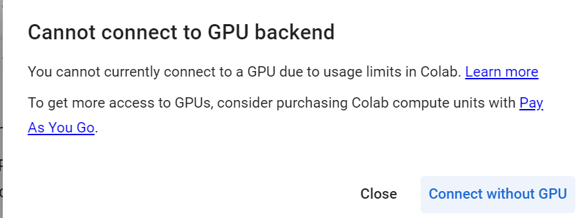

## **Installing and Importing Necessary Libraries**

```python
# installing the sentence-transformers and gensim libraries for word embeddings
!pip install -U sentence-transformers gensim tqdm transformers triton -q
```

```
   ━━━━━━━━━━━━━━━━━━━━━━━━━━━━━━━━━━━━━━━━ 493.7/493.7 kB 26.3 MB/s eta 0:00:00
   ━━━━━━━━━━━━━━━━━━━━━━━━━━━━━━━━━━━━━━━━ 27.9/27.9 MB 18.7 MB/s eta 0:00:00
   ━━━━━━━━━━━━━━━━━━━━━━━━━━━━━━━━━━━━━━━━ 170.5/170.5 MB 6.8 MB/s eta 0:00:00
```

```python
# Import libraries
from typing import Tuple

import datetime
import json
import gc
import math
import os
import platform
import psutil
import random
import time

# Third Party Libraries
import pandas as pd
import numpy as np
import matplotlib.pyplot as plt
import matplotlib.dates as mdates
import matplotlib.ticker as mticker
import seaborn as sns
from scipy.stats import randint

# Regular expressions for manipulating text data
import re
import tensorflow as tf

# Transformer Models
import torch
from sentence_transformers import SentenceTransformer

# For progress bar related functionalities
from tqdm import tqdm

# Stemming
import nltk

nltk.download('stopwords')  # loading the stopwords
nltk.download('wordnet')    # loading the wordnet module that is used in stemming

from nltk.corpus import stopwords
from nltk.stem.porter import PorterStemmer

# Tune model
from sklearn.ensemble import RandomForestClassifier
from sklearn.feature_extraction.text import CountVectorizer
from sklearn.linear_model import LogisticRegression
from sklearn.metrics import accuracy_score, confusion_matrix, classification_report, f1_score, precision_score, recall_score
from sklearn.model_selection import train_test_split, GridSearchCV, cross_val_score, RandomizedSearchCV, StratifiedKFold
from sklearn.preprocessing import LabelEncoder


# Sentiment Analysis
from transformers import pipeline

# Word2Vec
from gensim.models import Word2Vec, KeyedVectors
from gensim.scripts.glove2word2vec import glove2word2vec
```

```python
# Ignore unnecessary warnings
import warnings
warnings.filterwarnings("ignore")
```

```python
# ==================================
#  CONSTANTS
# ==================================

# Files
FILE_PATH = ''
FILE_NAME = 'source_data.csv'
CSV_FILE = FILE_PATH + FILE_NAME
W2V_FILE_NAME = 'glove.6B.100d.txt.word2vec'

# General
MSEC = 1000
SECS_IN_MIN = 60
SEED = 42
KBYTE = 1042
COMMON_WORD_CNT = 20

# Label Sentiments
# -1 = Negative sentiment, 0 = neutral, 1 = positive
LABEL_NEGATIVE = 'Negative'
LABEL_NEUTRAL = 'Neutral'
LABEL_POSITIVE = 'Positive'
LABEL_NEGATIVE_INT = -1
LABEL_NEUTRAL_INT = 0
LABEL_POSITIVE_INT = 1
LABEL_SENTIMENT = {
    LABEL_NEGATIVE_INT: LABEL_NEGATIVE,
    LABEL_NEUTRAL_INT: LABEL_NEUTRAL,
    LABEL_POSITIVE_INT: LABEL_POSITIVE
}

# Data Splits
HALF_DATA_SPLIT = 0.5
TEMPORARY_DATA_SPLIT = 0.2
TRAINING_DATA_SPLIT = 0.8

# Models
FITTING_GAP_THRESH = 0.05
FITTING_SCORE_THRESH = 0.75

# Model: Base Parameters
BASE_ESTIMATOR_CNT = 300
BASE_DEPTH_MAX = 15
BASE_LEAF_MIN = 6
BASE_SPLIT_MIN = 30 #10

# Model: Tuned Parameters
TUNED_ESTIMATOR_CNT = 500
TUNED_DEPTH_MAX = 7
TUNED_LEAF_MIN = 15
TUNED_SPLIT_MIN = 30 #10

CV_FOLDS = 5
CV_RANDOM_SEARCH_CNT = 25
USE_ALL_PROCS = -1
SENTENCE_TRANSFER_MODEL = 'sentence-transformers/all-MiniLM-L6-v2'

# Vectors
GLOVE_VECTOR_SIZE = 100
W2V_EPOCH_CNT = 40
W2V_VECTOR_SIZE = 300
VEC_MAX_SIZE = 1000
```

```python
# ==================================
#  HELPER FUNCTIONS
# ==================================

def start_timer() -> float:
    """
    Start a timer
    """
    return time.time()


def get_time(start_time_float: float) -> str:
    diff = abs(time.time() - start_time_float)
    hours, remainder = divmod(diff, SECS_IN_MIN*SECS_IN_MIN)
    minutes, seconds = divmod(remainder, SECS_IN_MIN)
    fractional_seconds = seconds - int(seconds)

    ms = fractional_seconds * MSEC
    return f"{int(minutes)}m {int(seconds)}s {int(ms)}ms"


def show_timer(start_time_float: float) -> None:
    print(f"\nRun Time: {get_time(start_time_float)}")


def show_banner(title: str, section: str='') -> None:
    """
    Prints a stylized banner for notebook readability, adjusted to remove
    the trailing hash symbol on the bottom line.

    +-------------------------------------+
    |                                     |
    +-------------------------------------+
    """

    PADDING = 2
    strlen = len(title) + PADDING
    line = '+-' + '-' * strlen + '-+'

    # Top Line
    print('')
    print(line)

    # Show Title
    print('|  ' + title.upper() + '  |')

    # Bottom Line
    print(line)

    # Show section (if provided)
    if section:
        print('| ' + section)

    print('') # Final newline for spacing


# Display performance by title
def show_performance(perf=None, title: str='') -> None:
    if not perf.empty:
        show_banner(title, 'Performance')
        print(f'{perf}')


def show_hardware_info():

    # Display number of CPU's
    show_banner('🖥 CPU Info')
    print(f'You have {os.cpu_count()} CPU cores available.')
    print(f"Processor: {platform.processor()}")
    print(f"System RAM: {psutil.virtual_memory().total / (KBYTE**3):.2f} GB")

    # Display number of GPU's
    print('')
    show_banner('🎮 GPU Info')
    print("Num GPUs Available: ", len(tf.config.list_physical_devices('GPU')))

    if torch.cuda.is_available():
        # Get the ID of the currently selected GPU (usually 0 in Colab)
        device_id = torch.cuda.current_device()
        device_name = torch.cuda.get_device_name(device_id)

        # Get properties using the ID
        device_props = torch.cuda.get_device_properties(device_id)

        print(f"Device ID: {device_id}")
        print(f"GPU Name: {device_name}")
        print(f"Total VRAM: {device_props.total_memory / (KBYTE**3):.2f} GB")
    else:
        print("⚠️ No GPU detected. Check Runtime > Change runtime type.")
```

```python
# Provide a visual progress bar when applying functions to DataFrames or Series, which helps track long-running operations.
tqdm.pandas()
torch.cuda.empty_cache()
gc_cnt = gc.collect()
print(f'Garbage Collection Count: {gc_cnt}')
del gc_cnt
```

```
Garbage Collection Count: 150
```

```python
# Show hardware info
show_hardware_info()
```

```
+--------------+
|  🖥 CPU INFO  |
+--------------+

You have 2 CPU cores available.
Processor: x86_64
System RAM: 12.03 GB


+--------------+
|  🎮 GPU INFO  |
+--------------+

Num GPUs Available:  0
⚠️ No GPU detected. Check Runtime > Change runtime type.
```

## **Loading the dataset**

```python
# Load data
data = pd.read_csv(CSV_FILE)
```

## **Data Overview**

```python
# Display head
data.head()
```

|  | date | news | open | high | low | close | volume | label |
| --- | --- | --- | --- | --- | --- | --- | --- | --- |
| 0 | 2019-01-02 | The tech sector experienced a significant dec... | 41.740002 | 42.244999 | 41.482498 | 40.246914 | 130672400 | -1 |
| 1 | 2019-01-02 | Apple lowered its fiscal Q1 revenue guidance ... | 41.740002 | 42.244999 | 41.482498 | 40.246914 | 130672400 | -1 |
| 2 | 2019-01-02 | Apple cut its fiscal first quarter revenue fo... | 41.740002 | 42.244999 | 41.482498 | 40.246914 | 130672400 | -1 |
| 3 | 2019-01-02 | This news article reports that yields on long... | 41.740002 | 42.244999 | 41.482498 | 40.246914 | 130672400 | -1 |
| 4 | 2019-01-02 | Apple's revenue warning led to a decline in U... | 41.740002 | 42.244999 | 41.482498 | 40.246914 | 130672400 | -1 |

```python
# Display tail
data.tail()
```

|  | date | news | open | high | low | close | volume | label |
| --- | --- | --- | --- | --- | --- | --- | --- | --- |
| 344 | 2019-04-30 | Media mogul Oprah Winfrey, known for influenc... | 50.764999 | 50.849998 | 49.7775 | 48.70879 | 186139600 | -1 |
| 345 | 2019-04-30 | European shares fell on Tuesday, with banks u... | 50.764999 | 50.849998 | 49.7775 | 48.70879 | 186139600 | -1 |
| 346 | 2019-04-30 | This article reports that the S&P 500 reached... | 50.764999 | 50.849998 | 49.7775 | 48.70879 | 186139600 | -1 |
| 347 | 2019-04-30 | The Federal Reserve is anticipated to keep in... | 50.764999 | 50.849998 | 49.7775 | 48.70879 | 186139600 | -1 |
| 348 | 2019-04-30 | In the first quarter, South Korea's Samsung E... | 50.764999 | 50.849998 | 49.7775 | 48.70879 | 186139600 | 0 |

```python
# Display shape structure
data.shape
```

```
(349, 8)
```

Dataset has 349 rows and 8 columns.

```python
# Display mean, median, min, max
data.describe().T
```

|  | count | mean | std | min | 25% | 50% | 75% | max |
| --- | --- | --- | --- | --- | --- | --- | --- | --- |
| open | 349.0 | 4.622923e+01 | 6.442817e+00 | 3.756750e+01 | 4.174000e+01 | 4.597500e+01 | 5.070750e+01 | 6.681750e+01 |
| high | 349.0 | 4.670046e+01 | 6.507321e+00 | 3.781750e+01 | 4.224500e+01 | 4.602500e+01 | 5.085000e+01 | 6.706250e+01 |
| low | 349.0 | 4.574539e+01 | 6.391976e+00 | 3.730500e+01 | 4.148250e+01 | 4.564000e+01 | 4.977750e+01 | 6.586250e+01 |
| close | 349.0 | 4.492632e+01 | 6.398338e+00 | 3.625413e+01 | 4.024691e+01 | 4.459692e+01 | 4.911079e+01 | 6.480523e+01 |
| volume | 349.0 | 1.289482e+08 | 4.317031e+07 | 4.544800e+07 | 1.032720e+08 | 1.156272e+08 | 1.511252e+08 | 2.444392e+08 |
| label | 349.0 | -5.444126e-02 | 7.151192e-01 | -1.000000e+00 | -1.000000e+00 | 0.000000e+00 | 0.000000e+00 | 1.000000e+00 |

```python
# Display column info
data.info()
```

```
<class 'pandas.core.frame.DataFrame'>
RangeIndex: 349 entries, 0 to 348
Data columns (total 8 columns):
 #   Column  Non-Null Count  Dtype
---  ------  --------------  -----
 0   date    349 non-null    object
 1   news    349 non-null    object
 2   open    349 non-null    float64
 3   high    349 non-null    float64
 4   low     349 non-null    float64
 5   close   349 non-null    float64
 6   volume  349 non-null    int64
 7   label   349 non-null    int64
dtypes: float64(4), int64(2), object(2)
memory usage: 21.9+ KB
```

```python
# Check for null values
data.isnull().sum()
```

|  | 0 |
| --- | --- |
| date | 0 |
| news | 0 |
| open | 0 |
| high | 0 |
| low | 0 |
| close | 0 |
| volume | 0 |
| label | 0 |

**dtype:** int64

There are no null values in the dataset.

```python
# Check for duplicate values
data.duplicated().sum()
```

```
np.int64(0)
```

There are no duplicate values in the dataset.

## **Exploratory Data Analysis**

### **Univariate Analysis**

- Distribution of individual variables
- Compute and check the distribution of the length of news content

```python
# Define label barchart
def labeled_barchart(df: pd.DataFrame, feature: str, perc: bool=False, n=None) -> None:
    """
    Barplot with percentage at the top

    df: dataframe
    feature: dataframe column
    perc: whether to display percentages instead of count default False
    n: displays the top n category levels default None
    """
    total = len(df[feature])
    count = df[feature].nunique()

    if n is None:
        plt.figure(figsize=(count + 1, 5))
    else:
        plt.figure(figsize=(n + 1, 5))  # Set the figure size

    plt.xticks(rotation=90, fontsize=15)

    ax = sns.countplot(
        data=df,
        x=feature,
        palette="Paired",
        order=df[feature].value_counts().index[:n].sort_values(),
    )

    for p in ax.patches:
        if perc == True:
            label = "{:.1f}%".format(100 * p.get_height() / total)

        else:
            label = p.get_height()
            x = p.get_x() + p.get_width() / 2
            y = p.get_height()

            ax.annotate(
                label,
                (x, y),
                ha="center",
                va="center",
                size=12,
                xytext=(0, 5),
                textcoords="offset points",
          )

    plt.show()
```

```python
def distribution_plot_wrt_target(data: pd.DataFrame, predictor: str, target: str) -> None:
    """
    Plots the distribution of a predictor variable with respect to a target variable.
    This function is robust and works for binary or multi-class targets.
    """
    # Set a clean and professional style
    plt.style.use('seaborn-v0_8-whitegrid')
    fig, axs = plt.subplots(1, 3, figsize=(20, 6)) # Changed to a 1x3 layout

    # --- Plot 1: Overlaid Histogram for all classes ---
    axs[0].set_title(f'Distribution of {predictor.title()} by {target.title()}', fontsize=14, fontweight='bold')
    sns.histplot(
        data=data,
        x=predictor,
        kde=True,
        ax=axs[0],
        hue=target, # Use hue to automatically separate classes
        palette='viridis', # A vibrant and clear color palette
        element='step' # Use steps for clearer overlap
    )
    axs[0].legend(title=target.title(), labels=data[target].unique())

    # --- Plot 2: Boxplot with outliers ---
    axs[1].set_title(f'Boxplot of {predictor.title()} by {target.title()}', fontsize=14, fontweight='bold')
    sns.boxplot(
        data=data, x=target, y=predictor, ax=axs[1], palette='magma'
    )

    # --- Plot 3: Boxplot without outliers ---
    axs[2].set_title(f'Boxplot of {predictor.title()} (No Outliers)', fontsize=14, fontweight='bold')
    sns.boxplot(
        data=data,
        x=target,
        y=predictor,
        ax=axs[2],
        showfliers=False, # Hide outliers for a clearer view of the distribution
        palette='plasma'
    )

    # --- Final Touches ---
    plt.tight_layout(pad=2.0)
    plt.show()
```

```python
# Define plot distributions
def distribution_plot_wrt_target_old(df: pd.DataFrame, predictor: pd.DataFrame, target: str) -> None:
  fig, axs = plt.subplots(2, 2, figsize=(12, 10))
  target_unique = df[target].unique()

  axs[0,0].set_title('Distribution of target for target=' + str(target))
  sns.histplot(
      data=df[df[target] == target_unique[0]],
      x=predictor,
      kde=True,
      ax=axs[0, 0],
      color='teal',
  )

  axs[0, 1].set_title('Distribution of target for target=' + str(target))
  sns.histplot(
      data=df[df[target] == target_unique[1]],
      x=predictor,
      kde=True,
      ax=axs[0, 1],
      color='orange',
  )

  axs[1, 0].set_title('Boxplot w/ respect to target=' + str(target))
  sns.boxplot(data=df, x=target, y=predictor, ax=axs[1,0], palette='gist_rainbow')

  axs[1, 1].set_title('Boxplot (w/o outliers) w/ respect to target')
  sns.boxplot(
      data=df,
      x=target,
      y=predictor,
      ax=axs[1, 1],
      showfliers=False,
      palette='gist_rainbow',
  )

  plt.tight_layout()
  plt.show()
```

```python
def histogram_boxplot(
    df: pd.DataFrame,
    feature: str,
    figsize: Tuple=(14, 8),
    kde: bool = True,
    bins=None,
    style: str='seaborn-v0_8-whitegrid',
) -> None:
    """
    Enhanced boxplot and histogram combined for aesthetic appeal.

    df: dataframe
    feature: dataframe column
    figsize: size of figure (default (14, 8))
    kde: whether to the show density curve (default True)
    bins: number of bins for histogram (default None)
    style: matplotlib style to use (default 'seaborn-v0_8-whitegrid')
    """

    # --- Set the Plot Style ---
    plt.style.use(style)

    # --- Create Subplots and Define Layout ---
    f2, (ax_box2, ax_hist2) = plt.subplots(
        nrows=2,  # Number of rows of the subplot grid = 2
        sharex=True,  # x-axis will be shared among all subplots
        gridspec_kw={"height_ratios": (0.25, 0.75)},
        figsize=figsize,
    )

    # --- Add a Main Title ---
    f2.suptitle(
        f"Distribution of {feature.title()} with Boxplot and Histogram",
        fontsize=16,
        fontweight='bold',
        color='#333333' # Dark gray title color
    )

    # --- Boxplot (ax_box2) ---
    box_color = "#1f77b4"  # A nice deep blue
    sns.boxplot(
        data=df,
        x=feature,
        ax=ax_box2,
        showmeans=True,
        color=box_color,
        meanprops={
            "marker": "o",
            "markerfacecolor": "white",
            "markeredgecolor": "red",
            "markersize": "8",
        },
        linewidth=1.5,
    )
    # Remove x-label from boxplot for cleaner look
    ax_box2.set_xlabel("")
    # Add minor grid lines for subtle detail
    ax_box2.grid(True, which='both', linestyle='--', linewidth=0.5, alpha=0.7)

    # --- Histogram (ax_hist2) ---
    hist_color = "#2ca02c" # A complimentary green
    # Select the appropriate histplot based on whether bins are specified
    if bins:
        sns.histplot(
            data=df, x=feature, kde=kde, ax=ax_hist2, bins=bins, color=hist_color
        )
    else:
        sns.histplot(
            data=df, x=feature, kde=kde, ax=ax_hist2, color=hist_color
        )

    # --- Add Mean and Median Lines with Enhancements ---
    mean_val = df[feature].mean()
    median_val = df[feature].median()

    # Mean line (dashed, vibrant red)
    ax_hist2.axvline(
        mean_val,
        color="#d62728",
        linestyle="--",
        linewidth=2.5,
        label=f"Mean: {mean_val:,.2f}",
    )

    # Median line (solid, dark orange)
    ax_hist2.axvline(
        median_val,
        color="#ff7f0e",
        linestyle="-",
        linewidth=2.5,
        label=f"Median: {median_val:,.2f}",
    )

    # Add Legend and Other Details ---
    ax_hist2.legend(loc='upper right', frameon=True, shadow=True, fancybox=True)
    ax_hist2.set_ylabel("Frequency / Count", fontsize=12)
    ax_hist2.set_xlabel(feature.title(), fontsize=12)

    # Add minor grid lines for subtle detail
    ax_hist2.grid(True, which='both', linestyle='--', linewidth=0.5, alpha=0.7)

    # Tight layout adjustment
    f2.tight_layout(rect=[0, 0, 1, 0.96]) # Adjust for suptitle

    # --- Optional: Display the figure ---
    plt.show()

# You would typically call this function after defining it, e.g.:
# # Assuming df is your DataFrame and 'Age' is the column:
# # histogram_boxplot_enhanced(df, 'Age', bins=30)
```

**Sentiment Analysis via Labeled Barchart**

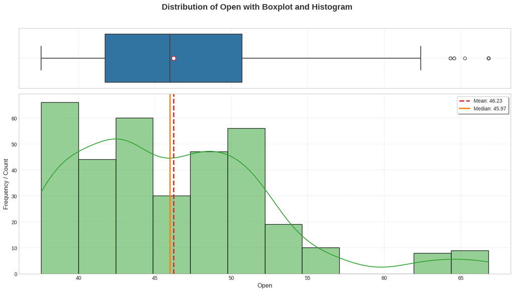

```python
# Define column Open
histogram_boxplot(data, 'open')
```

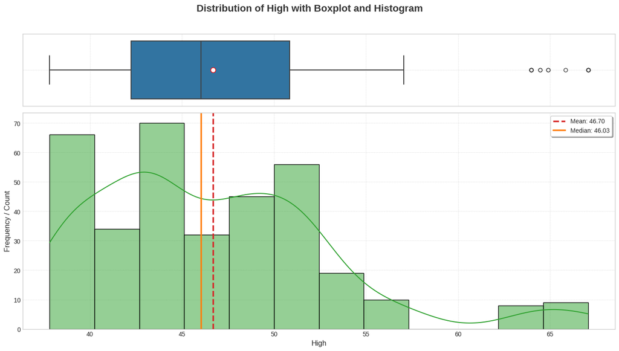

```python
# Define column high
histogram_boxplot(data, 'high')
```

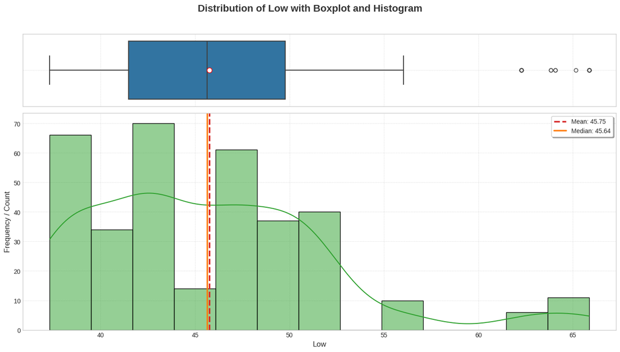

```python
histogram_boxplot(data, 'low')
```

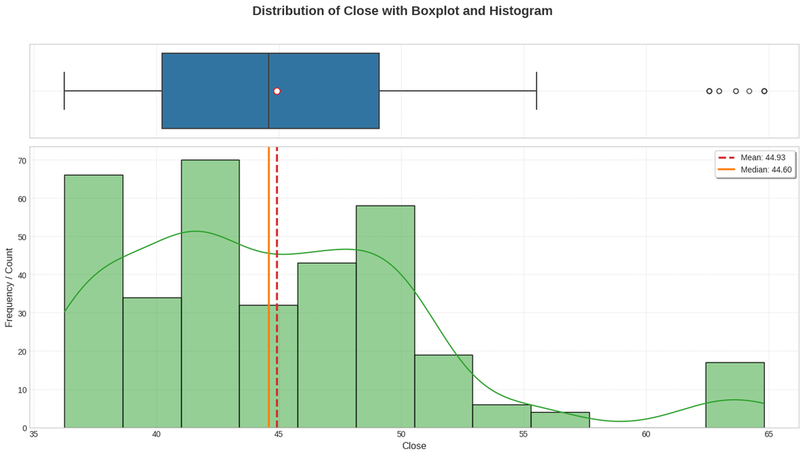

```python
# Define column close
histogram_boxplot(data, 'close')
```

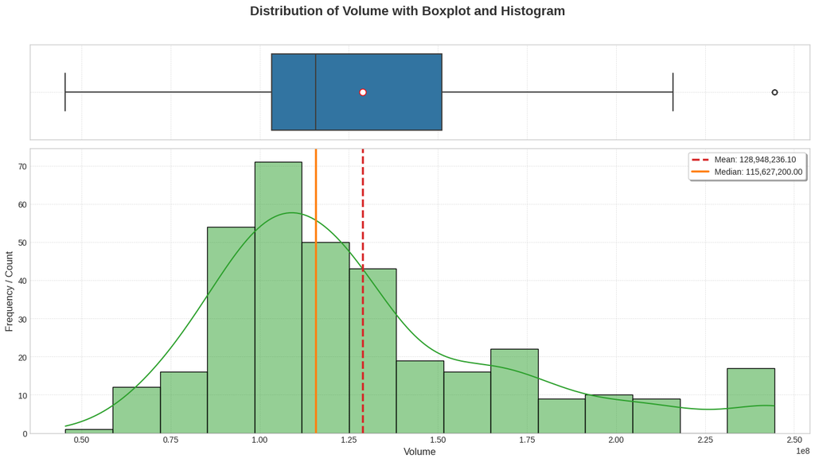

```python
# Define column volume
histogram_boxplot(data, 'volume')
```

```python
# Copy data to rename Label Sentiment and values -1, 0, 1 "Negative", "Neutral", "Positive"
chart_df = data.copy()
chart_df['label'] = chart_df['label'].replace(LABEL_SENTIMENT)
```

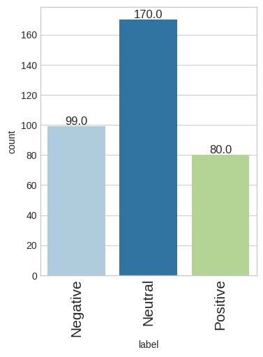

```python
# Define column label
labeled_barchart(chart_df, 'label')
```

```python
sentiment_titles = [LABEL_NEGATIVE, LABEL_NEUTRAL, LABEL_POSITIVE]
row_count = data.shape[0]
data_sentiment = data['label'].copy()
sentiment_counts = data_sentiment.value_counts()

show_banner('Sentiment Count')
for title, count in zip(sentiment_titles, sentiment_counts):
    pct = round((count / row_count) * 100, 2)
    print(f"{title}: {count} or {pct}%")

print('----------------------')
print(f'Total: {sentiment_counts.sum()} or 100%')
```

[output not shown]

News Sentiment counts are as follows:

- Negative 99 or 28.3%.
- Neutral 170 or 48.7%.
- Positive 80 or 22.9%.

**Distribution of word count**

```python
def plot_word_count_distribution(
    data: pd.DataFrame,
    word_count_column: str,
) -> None:
    """
    Enhanced histogram for visualizing the distribution of word counts.

    data: dataframe
    word_count_column: the column containing word counts (e.g., 'word_count')
    figsize: size of figure (default (12, 7))
    bins: number of bins for histogram (default 50 for more detail)
    style: matplotlib style to use (default 'seaborn-v0_8-darkgrid')
    color: color of the histogram bars
    """

    # --- Set the Plot Style ---
    plt.style.use('seaborn-v0_8-darkgrid')

    # Calculate key statistics for annotation
    counts = data[word_count_column].dropna()
    mean_val = counts.mean()
    median_val = counts.median()

    # --- Create the Figure and Axes ---
    plt.figure(figsize=(12, 7))

    # --- Plot the Histogram ---
    sns.histplot(
        counts,
        bins=50,
        color='#3A5A40',
        edgecolor='#2a2a2a', # Dark edge for contrast
        kde=True,            # Add a Kernel Density Estimate for smoothness
        linewidth=0.8,
        line_kws={
            'color': '#A3B18A',
            'linewidth': 3,
            'alpha': 0.8
        } # Lighter line for KDE
    )

    # --- Add Mean and Median Lines ---
    # Mean line (dashed, bright red)
    plt.axvline(
        mean_val,
        color='#d62728',
        linestyle='--',
        linewidth=2.5,
        label=f"Mean: {mean_val:,.2f}"
    )

    # Median line (dotted, dark orange)
    plt.axvline(
        median_val,
        color='#ff7f0e',
        linestyle=':',
        linewidth=2.5,
        label=f"Median: {median_val:,.2f}"
    )

    # --- Add Title and Labels ---
    column_str = word_count_column.replace('_', ' ').title()
    plt.title(
        f"Distribution of {column_str}",
        fontsize=18,
        fontweight='bold',
        pad=15 # Padding above the chart
    )
    plt.xlabel(column_str, fontsize=14, labelpad=10)
    plt.ylabel('Frequency', fontsize=14, labelpad=10)

    # --- Add Legend and Final Touches ---
    plt.legend(loc='upper right', frameon=True, shadow=True, fancybox=True)

    # Remove top and right spines for a cleaner look
    sns.despine(trim=True)

    # Ensure layout fits everything
    plt.tight_layout()

    plt.show()
```

```python
data['word_count'] = data['news'].apply(lambda x: len(str(x).split()))
```

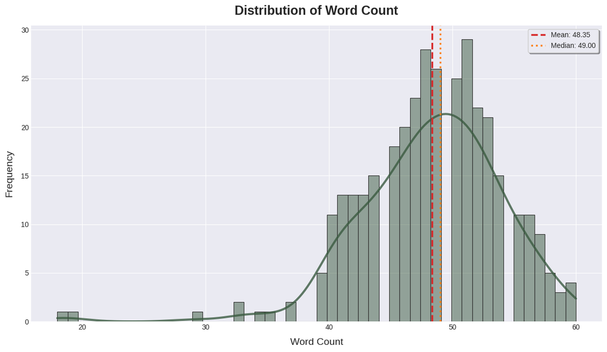

```python
plot_word_count_distribution(data, 'word_count')
```

As you can see most of the news stories are between 40 and 60 words. Very few times did words less than 40 make any head way.

### **Bivariate Analysis**

- Correlation
- Sentiment Polarity vs Price
- Date vs Price

**Note**: The above points are listed to provide guidance on how to approach bivariate analysis. Analysis has to be done beyond the above listed points to get maximum scores.

```python
def show_correlation_matrix(df: pd.DataFrame, matrix_title: str='Correlation Matrix') -> None:
    plt.figure(figsize=(14, 10))
    sns.heatmap(
        df,
        annot=True,
        cmap="coolwarm",
        fmt=".3f",
        vmin=-1,
        vmax=1
    )

    plt.title(matrix_title.title(), fontsize=16)
    plt.tight_layout()
    plt.savefig('stock_market_news_corr_matrix.png')
```

```python
# Get values for correlation matrix
matrix_df = data.sort_values(by='date')
matrix_df['date'] = pd.to_datetime(matrix_df['date'])
matrix_df['next_close'] = matrix_df['close'].shift(-1)

# Next Day Return
next_day_return = (matrix_df['next_close'] - matrix_df['close'])
matrix_df['next_day_return'] = (next_day_return / matrix_df['close'])
matrix_df = matrix_df.dropna(subset=['next_day_return'])

# Make columns readable
numerical_data = matrix_df.select_dtypes(include=['number'])
matrix_cols = [col.replace('_', ' ').title() for col in numerical_data.columns]
numerical_data.columns = matrix_cols

# Get correlation matrix
correlation_matrix = numerical_data.corr()
```

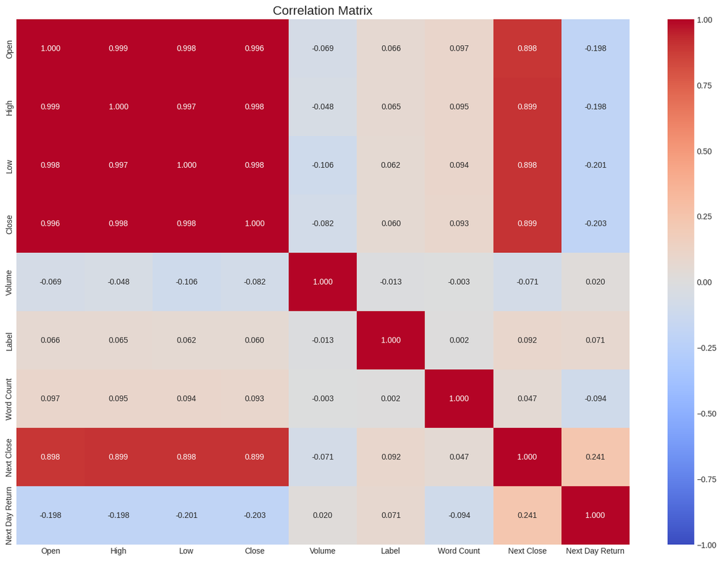

```python
show_correlation_matrix(correlation_matrix)
```

**Analysis of Correlation**

```python
def show_plot_stock_price(df: pd.DataFrame) -> None:
    # --- Enhanced Box Plotting ---
    sns.set_style("whitegrid")
    fig, axes = plt.subplots(2, 2, figsize=(14, 12))
    fig.suptitle('Distribution of Stock Prices by News Sentiment', fontsize=16, y=1.02)
    axes = axes.flatten()

    price_variables = ['open', 'high', 'low', 'close']

    for i, variable in enumerate(price_variables):
        variable_title = variable.title()
        sns.boxplot(
            data=df,
            x="label_text",
            y=variable,
            ax=axes[i],
            palette='viridis',
            medianprops={'color': 'red', 'linewidth': 2}
        )

        axes[i].set_title(f'{variable_title} Price by Sentiment', fontsize=14)
        axes[i].set_xlabel('News Sentiment', fontsize=12)
        axes[i].set_ylabel(f'Price ({variable_title})', fontsize=12)

    plt.tight_layout(pad=3.0)
    plt.savefig('stock_price_boxplots_enhanced.png')
```

```python
matrix_df['label_text'] = matrix_df['label'].map(LABEL_SENTIMENT)
```

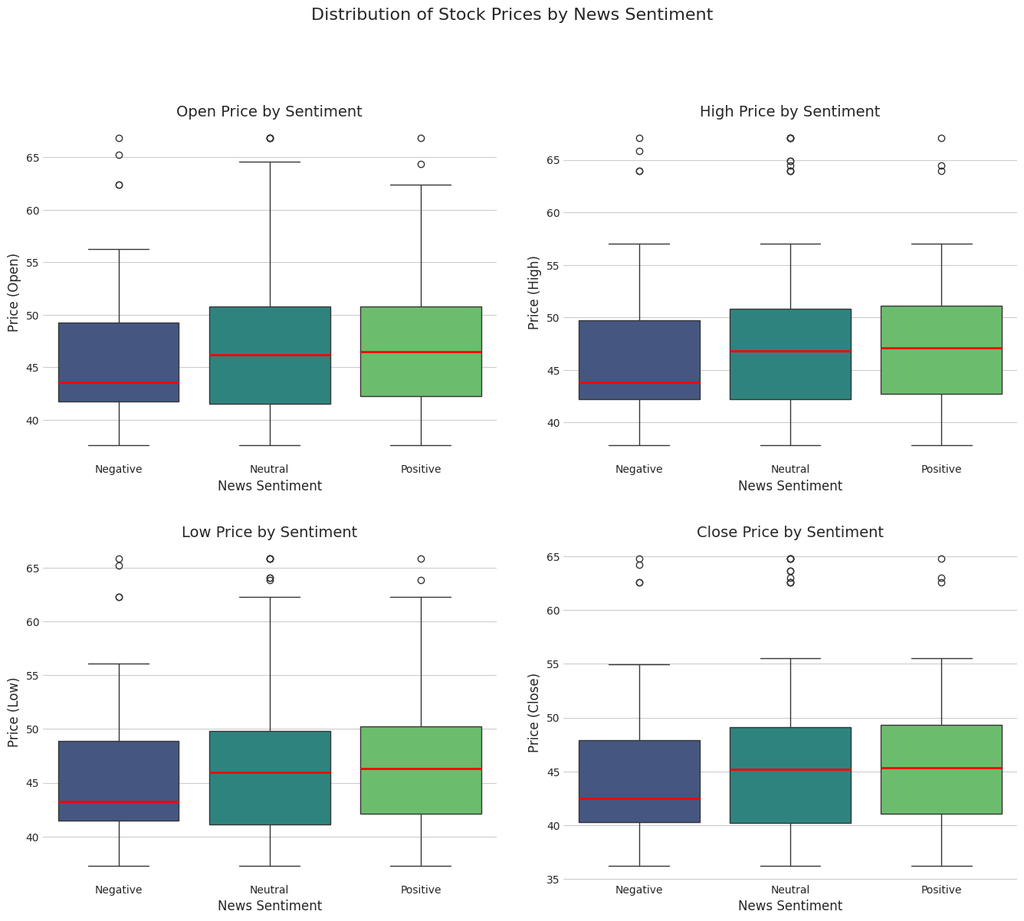

```python
# Display box for stock prices
show_plot_stock_price(matrix_df)
```

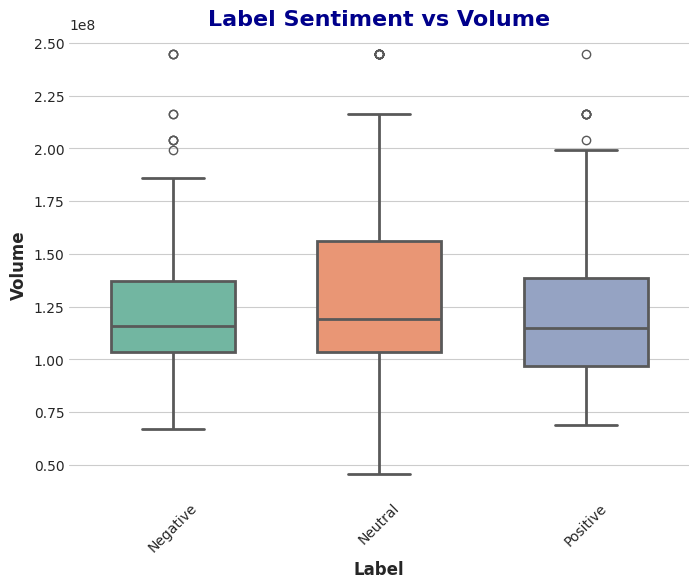

```python
# Display box plot to compare Label by volume

# Set a clean style
sns.set_style("whitegrid")

# Create the boxplot with improved aesthetics
plt.figure(figsize=(8, 6))  # Adjust figure size
sns.boxplot(
    data=chart_df,
    x="label",
    y="volume",
    palette="Set2",  # Change color scheme
    width=0.6,  # Adjust box width
    linewidth=2  # Make edges sharper
)

# Enhance titles and labels
plt.title("Label Sentiment vs Volume", fontsize=16, fontweight='bold', color="darkblue")
plt.xlabel("Label", fontsize=12, fontweight='bold')
plt.ylabel("Volume", fontsize=12, fontweight='bold')

# Rotate x-axis labels if needed
plt.xticks(rotation=45)

# Show the final chart
plt.show()
```

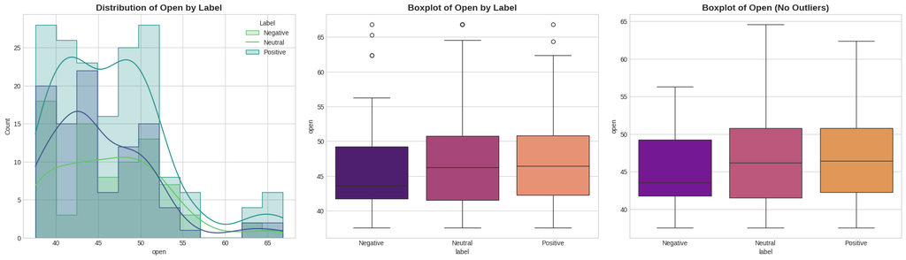

```python
# Use "Label" as target variable.
# Get distribution for Open
distribution_plot_wrt_target(chart_df, 'open', 'label')
```

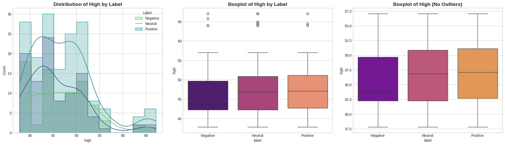

```python
# Get distribution for High
distribution_plot_wrt_target(chart_df, 'high', 'label')
```

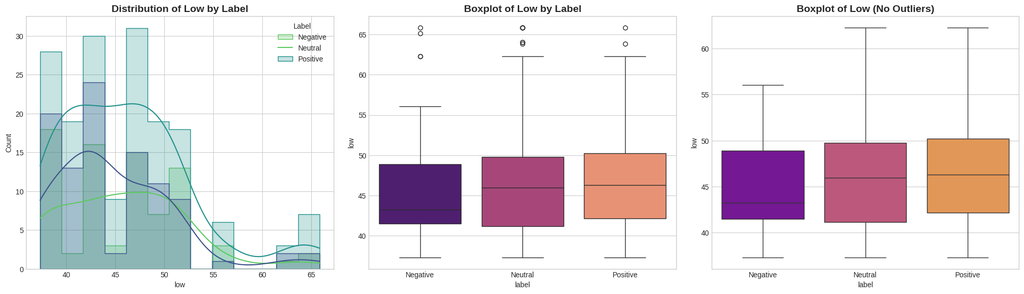

```python
# Get distribution for Low
distribution_plot_wrt_target(chart_df, 'low', 'label')
```

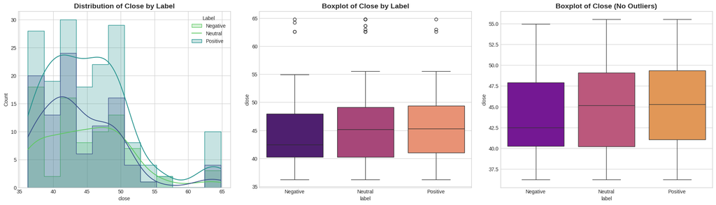

```python
# Get distribution for Close
distribution_plot_wrt_target(chart_df, 'close', 'label')
```

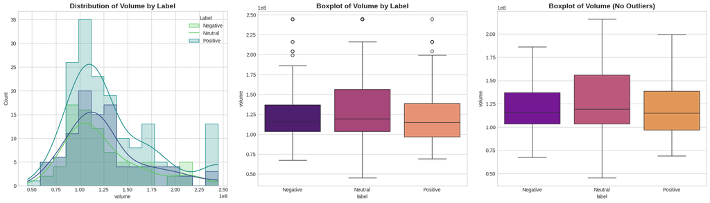

```python
# Get distribution for Volume
distribution_plot_wrt_target(chart_df, 'volume', 'label')
```

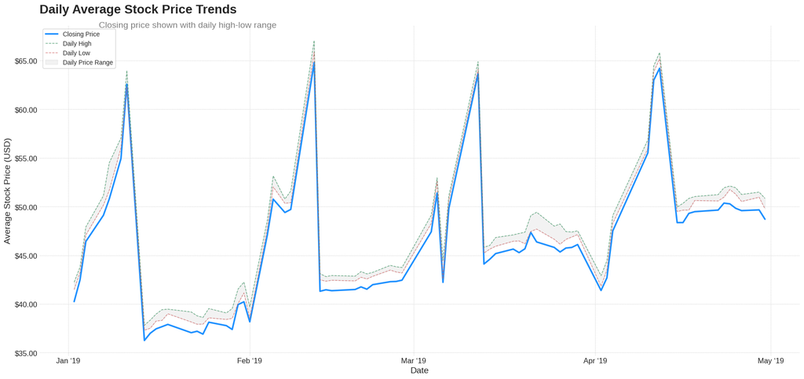

```python
# Get daily stock price averages
# Assuming 'data' DataFrame is available and loaded with 'date', 'open', 'high', 'low', 'close', 'volume'
daily_stock_prices = data.groupby('date').agg({
    'open': 'mean',
    'high': 'mean',
    'low': 'mean',
    'close': 'mean',
    'volume': 'mean',
}).reset_index()

daily_stock_prices.set_index('date', inplace=True)
daily_stock_prices.index = pd.to_datetime(daily_stock_prices.index)

# --- Enhanced Plotting ---
plt.style.use('seaborn-v0_8-whitegrid') # Use a clean, professional style
fig, ax = plt.subplots(figsize=(18, 9)) # Create figure and axes for more control

# --- Plot the Main Closing Price Line ---
# Make the 'close' price the most prominent line
sns.lineplot(
    x=daily_stock_prices.index,
    y=daily_stock_prices['close'],
    color='#1E90FF', # Dodger Blue for focus
    label='Closing Price',
    linewidth=2.5, # Thicker line for emphasis
    ax=ax
)

# --- Plot the High and Low Lines for Context ---
# Use thinner, less prominent lines for the daily range
sns.lineplot(
    x=daily_stock_prices.index,
    y=daily_stock_prices['high'],
    color='#2E8B57', # Sea Green for High
    label='Daily High',
    linewidth=1,
    linestyle='--',
    alpha=0.7,
    ax=ax
)
sns.lineplot(
    x=daily_stock_prices.index,
    y=daily_stock_prices['low'],
    color='#CD5C5C', # Indian Red for Low
    label='Daily Low',
    linewidth=1,
    linestyle='--',
    alpha=0.7,
    ax=ax
)

# --- Shade the Area between High and Low for Visual Range ---
ax.fill_between(
    daily_stock_prices.index,
    daily_stock_prices['low'],
    daily_stock_prices['high'],
    color='gray',
    alpha=0.1,  # Light shading
    label='Daily Price Range'
)

# --- Titles and Labels (Cleaner Approach) ---
# Use a single title block with a subtitle for better alignment
ax.set_title(
    'Daily Average Stock Price Trends',
    loc='left', # Align to the left for a modern look
    fontsize=20,
    fontweight='bold',
    pad=20
)
fig.text(
    0.125,
    0.875, # Position the subtitle manually below the title
    'Closing price shown with daily high-low range',
    ha='left',
    fontsize=14,
    color='gray'
)
ax.set_xlabel('Date', fontsize=14)
ax.set_ylabel('Average Stock Price (USD)', fontsize=14)

# --- Formatting X-axis (Date) ---
# Use locators for better tick spacing and formatters for readability
ax.xaxis.set_major_locator(mdates.MonthLocator()) # Tick for each month
ax.xaxis.set_minor_locator(mdates.WeekdayLocator(byweekday=mdates.MO)) # Minor tick for Mondays
ax.xaxis.set_major_formatter(mdates.DateFormatter('%b ‘%y')) # Format: Jan ‘25
plt.setp(ax.get_xticklabels(), rotation=0, ha='center') # No rotation needed with fewer ticks

# --- Formatting Y-axis (Currency) ---
ax.yaxis.set_major_formatter(mticker.FuncFormatter(lambda x, _: f'${x:,.2f}'))
ax.tick_params(axis='both', labelsize=12)

# --- Legend and Grid ---
ax.legend(loc='upper left', frameon=True, shadow=False)
ax.grid(True, which='major', linestyle='--', linewidth=0.5)

# --- Final Touches ---
sns.despine(left=True, bottom=True) # Remove top and right spines
plt.tight_layout(rect=[0, 0, 1, 0.95]) # Adjust layout to prevent title cutoff
plt.show()
```

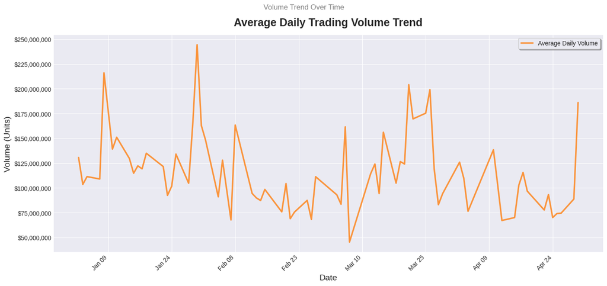

```python
# Show Volume during the same time period.
# Assuming 'daily_stock_prices' DataFrame is available from the previous steps
# and its index is already in datetime format.

# --- Enhanced Plotting ---
plt.style.use('seaborn-v0_8-darkgrid') # Use a clean, dark grid style

plt.figure(figsize=(14, 7))

# --- Use Line Plot for Volume (As Requested) ---
VOLUME_COLOR = '#FF7F0E' # A vibrant orange for emphasis

ax = sns.lineplot(
    x=daily_stock_prices.index,
    y=daily_stock_prices['volume'],
    color=VOLUME_COLOR,
    label='Average Daily Volume',
    linewidth=2.5,  # Make the line thicker
    alpha=0.8
)

# --- Titles and Labels ---
plt.title(
    'Average Daily Trading Volume Trend',
    fontsize=18,
    fontweight='bold',
    pad=15
)
plt.suptitle(
    'Volume Trend Over Time',
    fontsize=12,
    color='gray',
    y=0.93 # Position subtitle
)
plt.xlabel('Date', fontsize=14)
plt.ylabel('Volume (Units)', fontsize=14)

# --- Formatting x-axis (Date) ---
# Format the x-axis to show "Jan 11" instead of "2019-01-11"
ax.xaxis.set_major_formatter(mdates.DateFormatter('%b %d'))

# Set location of ticks to improve readability when many dates are present
ax.xaxis.set_major_locator(mticker.MaxNLocator(nbins=10))

plt.xticks(rotation=45, ha='right')

# --- Formatting y-axis (Large Numbers) ---
# Format y-axis to include commas for large volume numbers
ax.yaxis.set_major_formatter(mticker.FuncFormatter(lambda x, _: f'${x:,.0f}'))

# --- Final Touches ---
# Remove top and right spines for cleaner look
sns.despine(trim=True)

# Add Legend
plt.legend(loc='upper right', frameon=True, shadow=True, fancybox=True)
plt.tight_layout(rect=[0, 0, 1, 0.95]) # Adjust layout for suptitle

plt.show()
```

**Observations**

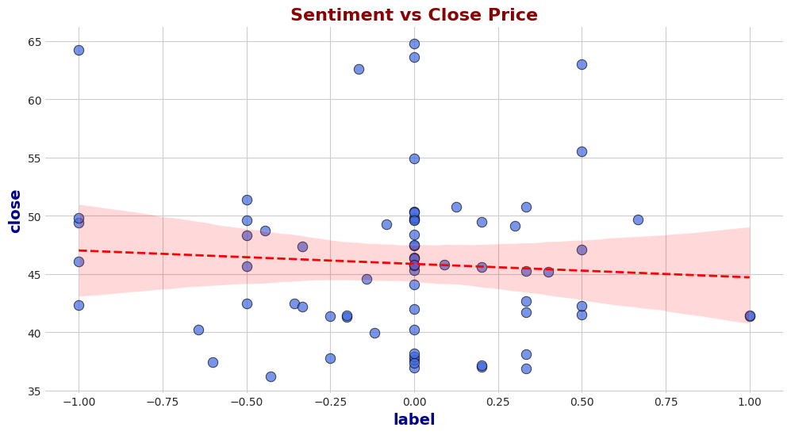

```python
# Get sentiment polarity
# Copy and preprocess data
sentiment_df = data.copy()
sentiment_df.drop('news', axis=1, inplace=True)  # Drop unnecessary column
sentiment_df['date'] = pd.to_datetime(data['date'])  # Ensure Date is in datetime format

# Select only numeric columns for averaging
numeric_columns = sentiment_df.select_dtypes(include=['number']).columns
data_grouped = sentiment_df.groupby('date')[numeric_columns].mean()  # Aggregate by Date

# Set figure size and style
plt.figure(figsize=(12, 6))
sns.set_style("whitegrid")  # Clean background

# Create scatter plot
sns.scatterplot(
    x=data_grouped['label'],
    y=data_grouped['close'],
    alpha=0.7,  # Adjust transparency for visibility
    color="royalblue",
    edgecolor="black",  # Improve contrast
    s=80  # Set point size
)

# Improve labels and title
plt.xlabel('Sentiment Polarity', fontsize=14, fontweight='bold', color='darkblue')
plt.ylabel('Close Price', fontsize=14, fontweight='bold', color='darkblue')
plt.title('Sentiment vs Close Price', fontsize=16, fontweight='bold', color='darkred')

# Add regression line for trend visualization
sns.regplot(
    x=data_grouped['label'],
    y=data_grouped['close'],
    scatter=False,  # Hide points (only show trend line)
    color='red',
    line_kws={"linewidth": 2, "linestyle": "--"}  # Make the trend line dashed
)

# Show final plot
plt.show()
```

**Observations**

## **Data Preprocessing**

```python
# Plot top words
def plot_top_word_freq() -> None:

    """
    Enhanced horizontal bar chart for visualizing the Top N most frequent words.

    words: list of all words (must correspond to word_counts)
    word_counts: list of all word frequencies (must correspond to words)
    top_n: Number of top words to display (default 20)
    figsize: size of figure (default (12, 8))
    style: matplotlib style to use (default 'seaborn-v0_8-white')
    palette: color palette to use (default 'viridis_r' - reversed viridis)
    """

    style = 'seaborn-v0_8-white',
    palette = 'viridis_r'

    # --- Prepare Data and Set Style ---
    plt.style.use(style)

    # Combine into a DataFrame for easy sorting and handling
    df_words = pd.DataFrame({
        'Word': words,
        'Frequency': word_counts
    }).sort_values(by='Frequency', ascending=False).head(COMMON_WORD_CNT)

    # --- Create the Figure ---
    plt.figure(figsize=(12, 8))

    # --- Plot the Bar Chart using Seaborn ---
    # Using barplot with order ensures bars are consistently sorted
    ax = sns.barplot(
        x='Frequency',
        y='Word',
        data=df_words,
        palette=palette,
        edgecolor='#333333',
        linewidth=0.5
    )

    # --- Add Data Labels (The "Bells & Whistles") ---
    for p in ax.patches:

        # Get the width of the bar (frequency value)
        width = p.get_width()

        # Place the label slightly after the end of the bar
        ax.annotate(
            f'{int(width):,}', # Format the count with commas
            (width, p.get_y() + p.get_height() / 2.),
            ha='left',
            va='center',
            xytext=(5, 0),  # 5 points horizontal offset
            textcoords='offset points',
            fontsize=11,
            color='black',
            fontweight='bold'
        )

    # --- Enhance Title and Labels ---
    plt.title(
        f"Top {COMMON_WORD_CNT} Most Frequent Words",
        fontsize=18,
        fontweight='bold',
        pad=15
    )
    plt.xlabel("Word Frequency", fontsize=14, labelpad=10)
    plt.ylabel("Word", fontsize=14, labelpad=10)

    # --- Final Touches ---
    # Customize the x-axis ticks to be integers
    max_freq = df_words['Frequency'].max()
    ax.set_xticks(ax.get_xticks()) # Keep current ticks
    ax.set_xticklabels([f'{int(x):,}' for x in ax.get_xticks()]) # Format ticks

    # Remove the surrounding frame (spines) for a cleaner look
    sns.despine(left=True, bottom=True)

    # Add a subtle grid on the x-axis
    ax.grid(axis='x', linestyle='--', alpha=0.6)

    plt.tight_layout()
    plt.show()
```

```python
# Remove special chars
def remove_special_chars(text: str) -> str:
    pattern = '[^A-Za-z0-9]+'
    text = ''.join(re.sub(pattern,' ', text))

    return text
```

```python
# Remove stop words
def remove_stopwords(text: str) -> str:
    # split text into separate words
    words = text.split()

    # remove English language stopwords
    new_text = ' '.join([word for word in words if word not in stopwords.words('english')])

    return new_text
```

```python
def apply_porter_stemmer(text: str) -> str:
    words = text.split()
    new_text = ' '.join([ps.stem(word) for word in words])

    return new_text
```

```python
# Output news to see if special chars are removed.
def show_news(df: pd.DataFrame, col: str='clean_text') -> pd.DataFrame:

    index = random.randint(0, df.shape[0])
    return df.loc[index:index + 5, ['news', col]]
```

```python
data['clean_text'] = data['news'].apply(remove_special_chars)
news = show_news(data)
news
```

|  | news | clean_text |
| --- | --- | --- |
| 118 | Tesla is considering Tianjin Lishen as a pote... | Tesla is considering Tianjin Lishen as a pote... |
| 119 | TomTom, a Dutch digital mapping company, agre... | TomTom a Dutch digital mapping company agreed... |
| 120 | Japan Display shares surged on reports of pot... | Japan Display shares surged on reports of pot... |
| 121 | The White House reportedly rejected a schedul... | The White House reportedly rejected a schedul... |
| 122 | Trump expressed optimism about ongoing trade ... | Trump expressed optimism about ongoing trade ... |
| 123 | Texas Inquiries reported fourth-quarter earni... | Texas Inquiries reported fourth quarter earni... |

```python
data['clean_text'] = data['news'].apply(remove_special_chars)
news = show_news(data)
news
```

|  | news | clean_text |
| --- | --- | --- |
| 143 | In after hours trading, Apple's shares rose d... | In after hours trading Apple s shares rose de... |
| 144 | Apple reported stronger-than-expected earning... | Apple reported stronger than expected earning... |
| 145 | 3M, the Minnesota-based manufacturing company,... | 3M the Minnesota based manufacturing company i... |
| 146 | Apple banned Facebook from its business app p... | Apple banned Facebook from its business app p... |
| 147 | AMD reported in-line earnings but missed reve... | AMD reported in line earnings but missed reve... |
| 148 | Google is reportedly operating a research app... | Google is reportedly operating a research app... |

```python
# Apply lowercasing
data['clean_text'] = data['clean_text'].str.lower()
news = show_news(data)
news
```

|  | news | clean_text |
| --- | --- | --- |
| 298 | In March, mobile phone shipments to China dro... | in march mobile phone shipments to china drop... |
| 299 | Oprah Winfrey and Prince Harry have partnered... | oprah winfrey and prince harry have partnered... |
| 300 | Google raised YouTube TV's monthly membership... | google raised youtube tv s monthly membership... |
| 301 | Delta Airlines' Q1 earnings surpassed expectat... | delta airlines q1 earnings surpassed expectati... |
| 302 | Apple is under investigation by the Dutch comp... | apple is under investigation by the dutch comp... |
| 303 | Apple has nearly doubled the number of suppli... | apple has nearly doubled the number of suppli... |

```python
# Remove the white space
data['clean_text'] = data['clean_text'].str.strip()
news = show_news(data)
news
```

|  | news | clean_text |
| --- | --- | --- |
| 3 | This news article reports that yields on long... | this news article reports that yields on long ... |
| 4 | Apple's revenue warning led to a decline in U... | apple s revenue warning led to a decline in us... |
| 5 | Apple CEO Tim Cook discussed the company's Q1 ... | apple ceo tim cook discussed the company s q1 ... |
| 6 | Roku Inc has announced plans to offer premium... | roku inc has announced plans to offer premium ... |
| 7 | Wall Street saw modest gains on Wednesday but... | wall street saw modest gains on wednesday but ... |
| 8 | Apple's fiscal first quarter revenue came in ... | apple s fiscal first quarter revenue came in b... |

```python
data['clean_text_wo_stop_words'] = data['clean_text'].apply(remove_stopwords)
news = show_news(data, 'clean_text_wo_stop_words')
news
```

|  | news | clean_text_wo_stop_words |
| --- | --- | --- |
| 175 | Two U.S. House Democrats, Frank Pallone and Ja... | two u house democrats frank pallone jan schako... |
| 176 | European shares surged to nine-week highs on ... | european shares surged nine week highs tuesday... |
| 177 | This news article reports that AMS, a sensor s... | news article reports ams sensor specialist sup... |
| 178 | Lumentum Holdings Inc expects Android smartph... | lumentum holdings inc expects android smartpho... |
| 179 | Wall Street rallied on Tuesday, with tech and... | wall street rallied tuesday tech consumer disc... |
| 180 | Apple's French division has reached an agreem... | apple french division reached agreement pay un... |

```python
# Apply stemming
ps = PorterStemmer()
```

```python
data['final_clean_text'] = data['clean_text_wo_stop_words'].apply(apply_porter_stemmer)

# Output news to see if stemming was applied
start = random.randint(0, data.shape[0])
end = random.randint(1, 5)

# Output news to see if stemming was applied
data.loc[start:start+end, ['news', 'clean_text_wo_stop_words', 'final_clean_text']]
```

|  | news | clean_text_wo_stop_words | final_clean_text |
| --- | --- | --- | --- |
| 314 | This news article reports that Apple Inc. fac... | news article reports apple inc faced securitie... | news articl report appl inc face secur fraud l... |
| 315 | Facebook, aiming to compete with Alexa, Siri,... | facebook aiming compete alexa siri google assi... | facebook aim compet alexa siri googl assist de... |
| 316 | Wisconsin Governor Tony Evers announced his i... | wisconsin governor tony evers announced intent... | wisconsin governor toni ever announc intent re... |
| 317 | On Wednesday, Morgan Stanley's revenue fell l... | wednesday morgan stanley revenue fell less exp... | wednesday morgan stanley revenu fell less expe... |
| 318 | In a move to combat rising robocalls and spam... | move combat rising robocalls spam mobile launc... | move combat rise robocal spam mobil launch new... |

```python
# Drop unneeded columns
data.drop(['clean_text', 'clean_text_wo_stop_words'], axis=1, inplace=True)
```

```python
# Text Vectorization

# Initializing CountVectorizer with the top 1000 words
bow_vec = CountVectorizer(max_features=VEC_MAX_SIZE)

# Apply TfidfVectorizer on data
data_features_BoW = bow_vec.fit_transform(data['final_clean_text'])

# Convert the data features to array
data_features_BoW = data_features_BoW.toarray()

# Shape of the feature vector
data_features_BoW.shape
```

```
(349, 1000)
```

Data features has 349 rows and 1000 columns.

```python
# Getting the 1000 words considered by the BoW model
words = bow_vec.get_feature_names_out()
```

```python
# Checking the words considered by BoW model
words
```

```
array(['000', '04', '06', '10', '100', '107', '11', '119', '13', '14',
       '15', '16', '17', '18', '189', '19', '195', '20', '200', '201',
       '2011', '2014', '2016', '2017', '2018', '2019', '2020', '21', '24',
       '25', '26', '28', '30', '300', '31', '36', '3d', '44', '49', '50',
       '500', '54', '5g', '60', '600', '67', '737', '75', '800', '84',
       '89', '93', '99', 'aac', 'aapl', 'accept', 'access', 'accord',
       'account', 'accus', 'acknowledg', 'acquisit', 'across', 'activ',
       'ad', 'addit', 'address', 'adjust', 'administr', 'adopt', 'advanc',
       'advantag', 'advertis', 'advis', 'aetna', 'affair', 'affect',
       'agenc', 'agre', 'agreement', 'ahead', 'aid', 'aim', 'air',
       'airpod', 'album', 'alexa', 'alibaba', 'alleg', 'allegedli',
       'allow', 'along', 'alphabet', 'alreadi', 'also', 'am', 'amazon',
       'american', 'amid', 'amidst', 'amount', 'analyst', 'android',
       'announc', 'annual', 'anoth', 'answer', 'anticip', 'antitrust',
       'app', 'appeal', 'appear', 'appl', 'appli', 'applic', 'approxim',
       'april', 'arabia', 'around', 'articl', 'asia', 'asian', 'asset',
       'assist', 'attempt', 'attribut', 'audio', 'australia', 'austrian',
       'author', 'auto', 'autom', 'automot', 'autonom', 'avail', 'averag',
       'avoid', 'await', 'back', 'balanc', 'ban', 'bank', 'barrel',
       'base', 'batteri', 'beat', 'becam', 'beij', 'believ', 'benefit',
       'berkshir', 'best', 'better', 'beyond', 'biggest', 'billion',
       'black', 'board', 'boe', 'bond', 'book', 'boost', 'brand', 'break',
       'brent', 'broadcom', 'broader', 'buffett', 'bug', 'build', 'bull',
       'bullish', 'busi', 'buy', 'buyback', 'bypass', 'byted', 'call',
       'came', 'camera', 'campaign', 'cancel', 'capit', 'car', 'card',
       'carmak', 'carrier', 'case', 'cash', 'caterpillar', 'caus',
       'cautiou', 'cb', 'center', 'central', 'ceo', 'chairman',
       'challeng', 'chang', 'channel', 'charg', 'chat', 'check', 'chief',
       'child', 'china', 'chines', 'chip', 'chipmak', 'cite', 'citi',
       'citizen', 'claim', 'clear', 'close', 'cloud', 'co', 'collabor',
       'com', 'come', 'comment', 'commerc', 'commiss', 'commission',
       'commit', 'commun', 'compani', 'compar', 'compet', 'competit',
       'competitor', 'complaint', 'compon', 'composit', 'concern',
       'confer', 'confid', 'consecut', 'consid', 'consum', 'content',
       'continu', 'contract', 'contribut', 'control', 'conveni', 'cook',
       'corp', 'corpor', 'cost', 'could', 'countri', 'court', 'crash',
       'creat', 'credit', 'critic', 'crude', 'cryptocurr', 'currenc',
       'current', 'curv', 'custom', 'cut', 'cybersecur', 'daili', 'damag',
       'data', 'day', 'deal', 'decad', 'decemb', 'decis', 'declin',
       'decreas', 'delay', 'delta', 'demand', 'deni', 'depart', 'design',
```

[output cut: 94 more lines]

```
       'thursday', 'tiktok', 'tim', 'time', 'token', 'tomtom', 'top',
       'total', 'toward', 'tpk', 'track', 'trade', 'treasuri', 'trend',
       'tri', 'trigger', 'trump', 'tsmc', 'tuesday', 'turn', 'tv',
       'tweet', 'two', 'uae', 'uala', 'uncertainti', 'underperform',
       'unexpect', 'unfair', 'union', 'unit', 'univers', 'unlimit',
       'unveil', 'upbeat', 'upcom', 'updat', 'upgrad', 'us', 'usd', 'use',
       'user', 'util', 'valu', 'valuat', 'variou', 'vehicl', 'vendor',
       'verizon', 'version', 'versu', 'vestag', 'viacom', 'vice', 'video',
       'view', 'violat', 'virtual', 'volatil', 'wall', 'war', 'warn',
       'warren', 'washington', 'watch', 'weak', 'weaken', 'weaker',
       'wednesday', 'week', 'well', 'whatsapp', 'white', 'wide', 'win',
       'winfrey', 'wireless', 'wisconsin', 'withdraw', 'withdrew',
       'within', 'without', 'worker', 'world', 'worth', 'would', 'wti',
       'xr', 'yaskawa', 'year', 'yen', 'yet', 'yield', 'york', 'yoy',
       'yuan', 'zeux', 'zone'], dtype=object)
```

```python
# Creating a DataFrame from the data features.
# This will be used as the independent variable when splitting data.
data_BoW = pd.DataFrame(data_features_BoW, columns=bow_vec.get_feature_names_out())
data_BoW.head()
```

|  | 000 | 04 | 06 | 10 | 100 | 107 | 11 | 119 | 13 | 14 | ... | yaskawa | year | yen | yet | yield | york | yoy | yuan | zeux | zone |
| --- | --- | --- | --- | --- | --- | --- | --- | --- | --- | --- | --- | --- | --- | --- | --- | --- | --- | --- | --- | --- | --- |
| 0 | 0 | 0 | 0 | 0 | 0 | 0 | 0 | 0 | 0 | 0 | ... | 0 | 0 | 0 | 0 | 0 | 0 | 0 | 0 | 0 | 0 |
| 1 | 0 | 0 | 0 | 1 | 0 | 0 | 0 | 0 | 0 | 0 | ... | 0 | 0 | 0 | 0 | 0 | 0 | 0 | 0 | 0 | 0 |
| 2 | 0 | 0 | 0 | 0 | 0 | 0 | 0 | 0 | 0 | 0 | ... | 0 | 0 | 0 | 0 | 0 | 0 | 0 | 0 | 0 | 0 |
| 3 | 0 | 0 | 0 | 0 | 0 | 0 | 0 | 0 | 0 | 0 | ... | 0 | 1 | 0 | 0 | 1 | 0 | 0 | 0 | 0 | 0 |
| 4 | 0 | 0 | 0 | 0 | 0 | 0 | 0 | 0 | 0 | 0 | ... | 0 | 0 | 1 | 0 | 0 | 0 | 0 | 0 | 0 | 0 |

5 rows × 1000 columns

From the above dataframe, we can observe that the word *yield* and *year* is present only in the fourth document, and the word *yen* (Japanese currency) is present once in the fifth document.

```python
# Visualize word importance.
# Get the top 20 most common words
word_counts = np.array(data_BoW.sum(axis=0))
words = bow_vec.get_feature_names_out()
top_words = np.argsort(word_counts)[::-1][:COMMON_WORD_CNT]
```

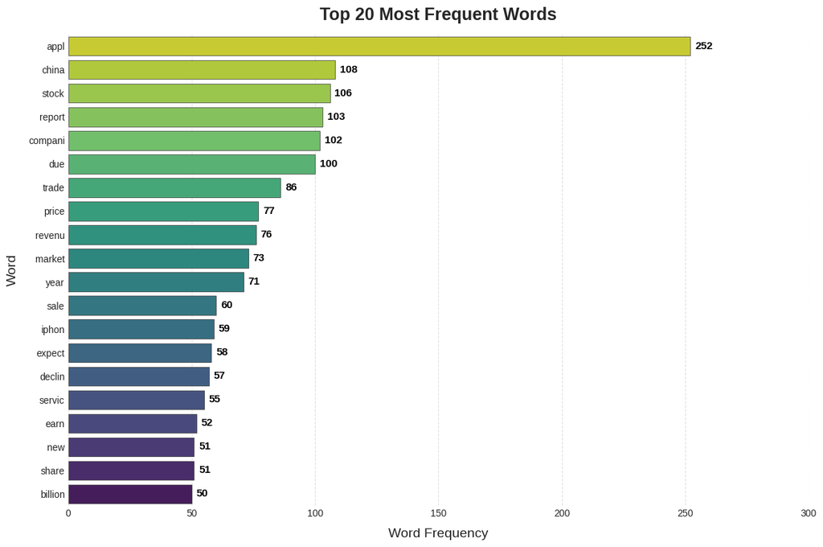

```python
plot_top_word_freq()
```

**Observations**

- Companies, industries, markets, quantity and financial jargon are the most common used words in the News.
- Apple Inc., is overwhelming discussed the most as they're a top 5 global company.
- China is the most frequently quoted country as they have the second largest population.

### Splitting Data

```python
# ===========================================
#  CREATE TRAINING, VALIDATION, TESTING DATA
# ===========================================
#
# https://scikit-learn.org/stable/modules/generated/sklearn.model_selection.train_test_split.html
#
# Training Data ~ 80%
# Validation Data ~ 10%
# Testing Data ~ 10%
#
# Define input (X) and target labels (y)

# INDEPENDENT VARIABLES aka features
features_df = X = data['final_clean_text']

# DEPENDENT VARIABLE aka target
target_df = y = data['label']

x_training_data = None
y_training_data = None
x_temp_data = None
y_temp_data = None

x_validation_data = None
y_validation_data = None
x_testing_data = None
y_testing_data = None

# Split data into 80% train, 20% temporary (to be split into validation & test)
x_training_data, x_temp_data, y_training_data, y_temp_data = train_test_split(
    features_df,
    target_df,
    test_size=TEMPORARY_DATA_SPLIT,
    stratify=target_df,
    random_state=SEED
)

# Further split temporary set into 10% validation, 10% test
x_validation_data, x_testing_data, y_validation_data, y_testing_data = train_test_split(
    x_temp_data,
    y_temp_data,
    test_size=HALF_DATA_SPLIT,
    stratify=y_temp_data,
    random_state=SEED
)
```

```python
# Printing the shapes
show_banner('Data Shapes')

print(f'Shape of X training: {x_training_data.shape}')
print(f'Shape of Y training: {y_training_data.shape}')
print(f'Shape of X validation: {x_validation_data.shape}')
print(f'Shape of Y validation: {y_validation_data.shape}')
print(f'Shape of X testing: {x_testing_data.shape}')
print(f'Shape of Y testing: {y_testing_data.shape}')

show_banner('Data Types')
print(f'Data type of X training: {x_training_data.dtype}')
print(f'Data type of Y training: {y_training_data.dtype}')
print(f'Data type of X validation: {x_validation_data.dtype}')
print(f'Data type of Y validation: {y_validation_data.dtype}')
print(f'Data type of X testing: {x_testing_data.dtype}')
print(f'Data type of Y testing: {y_testing_data.dtype}')
```

```
+---------------+
|  DATA SHAPES  |
+---------------+

Shape of X training: (279,)
Shape of Y training: (279,)
Shape of X validation: (35,)
Shape of Y validation: (35,)
Shape of X testing: (35,)
Shape of Y testing: (35,)

+--------------+
|  DATA TYPES  |
+--------------+

Data type of X training: object
Data type of Y training: int64
Data type of X validation: object
Data type of Y validation: int64
Data type of X testing: object
Data type of Y testing: int64
```

### **Word Embeddings**

```python
# Get vector cols
def get_vector_columns(vector_size: int) -> list:
    return ['Feature ' + str(i) for i in range(vector_size)]
```

```python
# Calculates the average vector value of a document list regardless of embedding type.
def calculate_mean_word_vectors(doc: str, word_vector_dict: dict, vocab: set, vector_size: int) -> np.ndarray:

    # Initialize a randomized list with noise to store word vectors, use the Generator's uniform method.
    rng = np.random.default_rng(SEED)
    feature_vector = rng.uniform(-0.01, 0.01, vector_size)

    # It splits the document into words and keeps only the words that exist in
    # the trained model's vocabulary
    doc_list = [word for word in doc.split() if word in vocab]

    # Calculate the average vector value of the words in the document that
    # are also in the vocabulary dataset.
    if doc_list:
        feature_vector = np.mean([word_vector_dict[word] for word in doc_list], axis=0)

    return feature_vector
```

```python
def encode_embeddings(
    x_training: pd.DataFrame,
    x_validation: pd.DataFrame,
    x_testing: pd.DataFrame,
    word_vector_dict: dict,
    vocab: set,
    vector_size: int,
    vector_cols: list
) -> Tuple[np.ndarray, np.ndarray, np.ndarray]:

    # --- Define the Nested Wrapper Function ---
    # This function is defined inside encode_embeddings, allowing it to "see"
    # all the input arguments (word_vector_dict, vocabulary, vector_size).
    # It only accepts the 'doc' string passed by the .apply() method.
    def vectorizer(doc: str):
        return calculate_mean_word_vectors(
            doc,
            word_vector_dict,
            vocab,
            vector_size
        )

    x_training_data_emb = pd.DataFrame(
        pd.Series(x_training).apply(vectorizer).tolist(),
        columns=vector_cols
    )

    x_validation_data_emb = pd.DataFrame(
        pd.Series(x_validation).apply(vectorizer).tolist(),
        columns=vector_cols
    )

    x_testing_data_emb = pd.DataFrame(
        pd.Series(x_testing).apply(vectorizer).tolist(),
        columns=vector_cols
    )

    return x_training_data_emb, x_validation_data_emb, x_testing_data_emb
```

### **Word2Vec**

```python
# Init values
w2v_vector_columns = get_vector_columns(W2V_VECTOR_SIZE)
random.choice(w2v_vector_columns)
```

```
'Feature 195'
```

```python
# Creating a list of all words in our data.
word_list = [item.split(' ') for item in data['final_clean_text'].values]
```

```python
# Creating an instance of Word2Vec
start_time = start_timer()

w2v_model = Word2Vec(
    sentences=word_list,
    vector_size= W2V_VECTOR_SIZE,
    window=5,
    min_count=2,
    workers=4,
    sg=1,
    epochs=W2V_EPOCH_CNT,
    seed=SEED
)

show_timer(start_time)
```

```
Run Time: 0m 3s 825ms
```

```python
# Retrieving the words present in the Word2Vec model's vocabulary.
vocabulary = set(w2v_model.wv.key_to_index.keys())

# Creating a list of word vectors.
word_vectors = w2v_model.wv[list(vocabulary)].tolist()

# Creating a dictionary of vocabulary and their corresponding vectors.
w2v_word_vector_dict = dict(zip(vocabulary, word_vectors))

print(f'Vocabulary Length: {len(vocabulary)}')
```

```
Vocabulary Length: 1405
```

```python
# Checking the word embedding of a random word
random_word = random.choice(list(vocabulary))

if random_word in w2v_model.wv:
    word_index = w2v_model.wv.key_to_index[random_word]
    print(f'W2V random word `{random_word}` is at index {word_index}.')
else:
    print(f'`{random_word}` not found!')
```

```
W2V random word `head` is at index 820.
```

```python
# Encode W2V embeddings
x_training_data_w2v, x_validation_data_w2v, x_testing_data_w2v = encode_embeddings(
    x_training_data,
    x_validation_data,
    x_testing_data,
    w2v_word_vector_dict,
    vocabulary,
    W2V_VECTOR_SIZE,
    w2v_vector_columns
)
```

```python
# Output split data
show_banner('Word2Vec Split Data')

print(f'x_training_data shape: {x_training_data_w2v.shape}')
print(f'x_testing_data shape: {x_testing_data_w2v.shape}')
print(f'x_validation_data shape: {x_validation_data_w2v.shape}')
```

```
+-----------------------+
|  WORD2VEC SPLIT DATA  |
+-----------------------+

x_training_data shape: (279, 300)
x_testing_data shape: (35, 300)
x_validation_data shape: (35, 300)
```

### **GloVe**

```python
# Global Vectors for Word Representation
w2v_path = FILE_PATH + W2V_FILE_NAME
w2V_BINARY_PATH = w2v_path + '_gensim_binary'
```

```python
start_time = start_timer()

if os.path.exists(w2V_BINARY_PATH):
    # Next time, you can load it instantly with:
    gloVe_model = KeyedVectors.load(w2V_BINARY_PATH)
    print(f'Loaded {w2V_BINARY_PATH}.')

else:
    # Load the Stanford gloVe model
    gloVe_model = KeyedVectors.load_word2vec_format(w2v_path, binary=False)

    # Save the model in Gensim's binary format for fast loading later
    print(f'Saving {w2v_path} to {w2V_BINARY_PATH}')
    gloVe_model.save(w2V_BINARY_PATH)

show_timer(start_time)
```

```
Loaded glove.6B.100d.txt.word2vec_gensim_binary.

Run Time: 0m 0s 552ms
```

```python
# Set vector size
gloVe_vector_columns = get_vector_columns(GLOVE_VECTOR_SIZE)
random.choice(gloVe_vector_columns)
```

```
'Feature 83'
```

```python
# Retrieving the words present in the GloVe model's vocabulary.
gloVe_vocabulary_list = list(gloVe_model.index_to_key)

# Creating a dictionary of words and their corresponding vectors.
gloVe_word_vector_dict = dict(zip(gloVe_vocabulary_list, list(gloVe_model.vectors)))

# And if you need a set for quick lookups:
vocabulary = set(gloVe_vocabulary_list)

print(f'GloVe Vocabulary Length: {len(vocabulary)}')
```

```
GloVe Vocabulary Length: 400000
```

```python
# Check random words
random_word = random.choice(list(vocabulary))

if random_word in gloVe_model:
    print(f'GloVe random word is `{random_word}`.\n\n Embedded:{gloVe_model[random_word]}')
```

```
GloVe random word is `almendares`.

 Embedded:[ 0.75858   -0.034903  -0.86067    0.074426  -0.086674  -0.055115
  0.62728   -0.068144   0.22428   -0.39897    0.21752   -0.22624
 -0.32059   -0.42133   -0.19805    0.6711     0.010105   0.10543
  0.22355   -0.03857   -0.072851   0.13815   -0.25805    0.098019
 -0.3094     0.048912  -0.57572   -0.24586    0.21431    0.29173
 -0.18473   -0.027736  -0.10846   -0.20902    0.023339  -0.039615
  0.02744    0.41053   -0.16211   -0.51587   -0.040159   0.068202
 -0.51924   -0.2032     0.13908    0.83368    0.049085   0.15365
 -0.0016692  1.0388    -0.1797     0.9942    -0.52617   -0.21948
  0.0092096  0.46607   -0.15773    0.032377  -1.2291     0.3902
 -0.65269   -0.3114    -0.042273  -0.28191   -0.50076    0.37923
 -0.45162    0.061215  -0.40022    0.10579    0.11147    0.18897
  0.099624   0.60896    0.18185    0.58419   -0.20652    0.23486
  0.24531   -0.11071    0.066935   0.039679   0.18249   -0.020844
  0.67795   -0.19393   -0.38112    0.48965   -0.075849   0.11287
 -0.39446   -0.32612   -0.25035   -0.25528    0.049814  -0.64802
 -0.5955     0.027326   0.44302   -0.13241  ]
```

**Splitting the dataset for GloVe**

```python
x_training_data_gloVe, x_validation_data_gloVe, x_testing_data_gloVe, = encode_embeddings(
    x_training_data,
    x_validation_data,
    x_testing_data,
    gloVe_word_vector_dict,
    vocabulary,
    GLOVE_VECTOR_SIZE,
    gloVe_vector_columns
)
```

```python
# Output split data
show_banner('gloVe Split Data')

print(f'x_training_data shape: {x_training_data_gloVe.shape}')
print(f'x_validation_data shape: {x_validation_data_gloVe.shape}')
print(f'x_testing_data shape: {x_testing_data_gloVe.shape}')
```

```
+--------------------+
|  GLOVE SPLIT DATA  |
+--------------------+

x_training_data shape: (279, 100)
x_validation_data shape: (35, 100)
x_testing_data shape: (35, 100)
```

### **Sentence Transformer**

```python
device_name = torch.device('cuda' if torch.cuda.is_available() else 'cpu')
```

```python
def encode_model(mod: SentenceTransformer, st_data: pd.DataFrame) -> np.ndarray:
    return mod.encode(
        st_data.tolist(),
        device=device_name,
        show_progress_bar=True
    )
```

```python
# Getting data for Sentence Transformer
st_model = SentenceTransformer(SENTENCE_TRANSFER_MODEL)
```

**Splitting the dataset for Sentence Transformer**

```python
# Encoding the dataset with a Sentence Transformer model.
x_training_data_st = encode_model(st_model, x_training_data)
x_validation_data_st = encode_model(st_model, x_validation_data)
x_testing_data_st = encode_model(st_model, x_testing_data)

# Output split data
show_banner('Sentence Transformer', 'Split Data')
print(f'x_training_data shape: {x_training_data_st.shape}')
print(f'x_validation_data shape: {x_validation_data_st.shape}')
print(f'x_testing_data shape: {x_testing_data_st.shape}')

# Note: Saving this data can save time.  Save data as npy
# x_training_data_st = np.load('content/drive/_____/x_training_data_st.npy')
```

```
+------------------------+
|  SENTENCE TRANSFORMER  |
+------------------------+
| Split Data

x_training_data shape: (279, 384)
x_validation_data shape: (35, 384)
x_testing_data shape: (35, 384)
```

Sentence Transformer Training data has 279 rows and 384 columns.

```python
# Printing the embedding vector of the first review in the dataset
x_training_data_st[0,:]
```

```
array([-5.67595661e-02, -9.68302973e-03,  3.18235857e-03, -1.30952224e-01,
       -4.80720066e-02,  2.76631918e-02,  2.79802941e-02,  1.93296429e-02,
        5.66851310e-02,  1.06210902e-01, -2.02166438e-02, -2.32288335e-02,
       -6.00026995e-02, -4.04327326e-02,  4.01944295e-02, -5.73457181e-02,
       -7.63421729e-02, -7.11552873e-02, -4.19608057e-02, -6.73840195e-02,
        4.94237393e-02, -2.99190674e-02, -3.77684385e-02, -1.93065703e-02,
        1.05711948e-02, -4.83884513e-02,  1.97726507e-02,  9.19481292e-02,
        4.00570817e-02, -2.60501392e-02,  8.63588974e-03,  5.79550304e-02,
       -1.49440335e-03,  5.23435920e-02,  5.82015564e-05, -7.60575803e-03,
       -2.03057900e-02, -7.84882605e-02, -4.94190343e-02, -1.37731833e-02,
        5.41533856e-03, -1.07069165e-01, -8.90177116e-02,  1.85104422e-02,
        1.09266751e-02, -3.37964110e-02, -5.98973148e-02,  3.63067873e-02,
        6.91242516e-02,  9.93161574e-02, -5.57316430e-02, -5.39173968e-02,
       -6.95898430e-03, -3.04745622e-02, -5.01561165e-02,  6.57619610e-02,
       -5.92864491e-02,  1.00689702e-01,  9.14382488e-02, -5.91095760e-02,
       -1.10553196e-02,  8.05293955e-03, -9.87419114e-03,  6.60320967e-02,
       -3.56138907e-02, -1.79415811e-02, -5.55443019e-02,  3.90474834e-02,
       -1.38003565e-02, -3.28632295e-02, -6.04852065e-02, -1.00949034e-02,
        4.76537608e-02, -5.90320341e-02, -9.46354792e-02,  9.44295712e-03,
        2.04743855e-02, -3.58550139e-02, -2.51867273e-03, -1.91240734e-03,
       -1.82143860e-02,  2.11954443e-03, -5.90693243e-02,  1.07270896e-01,
       -4.42794152e-02,  2.83069927e-02,  2.80781323e-03, -7.99912121e-03,
        6.09710030e-02, -4.91237156e-02, -4.59758453e-02, -4.47741011e-03,
        6.02122881e-02, -5.76019636e-04, -6.17350005e-02,  1.74952559e-02,
       -1.76458918e-02, -9.04760435e-02, -4.63270396e-02,  5.32819703e-02,
        6.89104712e-03,  6.55798689e-02,  5.08592092e-02,  2.43159886e-02,
       -1.65218711e-02, -5.73779158e-02, -3.20843700e-03,  2.40599159e-02,
       -1.86794195e-02,  2.08239526e-05, -9.12285373e-02,  6.96856454e-02,
       -3.30329873e-02, -8.25740248e-02,  1.13202641e-02,  9.35891420e-02,
       -4.42076698e-02,  4.71302345e-02,  1.29876910e-02, -5.11976192e-03,
        6.96032867e-02, -2.59788893e-02, -5.59957661e-02,  3.95165524e-03,
       -2.47060545e-02,  2.50933543e-02,  1.02180921e-01,  1.75318855e-32,
       -3.55479419e-02, -3.05540692e-02,  3.49293798e-02, -1.05356118e-02,
       -4.81067738e-03, -5.90125769e-02,  7.80399665e-02,  8.94881561e-02,
       -1.08305573e-01, -3.90253514e-02, -9.35849324e-02,  4.37921621e-02,
       -4.98050712e-02, -4.39889841e-02,  5.79030905e-03, -9.81363803e-02,
        3.93952876e-02,  2.16930248e-02,  7.62104243e-02, -9.89029650e-03,
       -3.33760912e-03, -2.42097843e-02,  5.73421456e-02, -4.63574491e-02,
        4.42831917e-03, -2.37048278e-03,  1.61245484e-02, -5.73619939e-02,
        9.86391604e-02,  4.20923196e-02,  8.69946256e-02, -2.12780852e-03,
```

[output cut: 42 more lines]

```
        9.69058871e-02, -3.38867456e-02, -8.17254782e-02, -3.72825563e-02,
       -2.37555224e-02,  5.43119125e-02,  2.81448513e-02,  3.96384224e-02,
       -7.61382421e-03,  1.65814459e-02,  1.59704604e-03, -6.74184561e-02,
        5.42284511e-02, -1.55546563e-02,  3.86115350e-02,  1.30192479e-02,
        1.27858552e-03,  9.17398185e-03,  1.97979137e-02,  1.87557209e-02,
        4.05032076e-02,  2.04949826e-02, -1.20387599e-02,  1.50495348e-03,
        4.43810187e-02, -5.98605685e-02,  3.34960334e-02, -2.75383852e-02,
        4.72610525e-04, -6.00073766e-03, -8.13804846e-03,  5.15193939e-02,
        5.03843017e-02,  2.68663540e-02,  5.21356389e-02, -3.61152813e-02,
        2.82902410e-03,  5.15249297e-02, -1.07292812e-02, -4.24479581e-02,
        8.70493725e-02, -5.09306714e-02, -6.43931404e-02,  6.13925494e-02,
        4.64836657e-02, -1.18935015e-03,  6.24864101e-02,  5.16661182e-02,
        4.71262820e-02, -7.28978366e-02, -4.24514757e-03,  1.09607102e-02,
        1.98895689e-02,  2.18727663e-02, -6.67081401e-02, -3.97461876e-02],
      dtype=float32)
```

## **Sentiment Analysis**

```python
# Define Plot Confusion Matrix
def plot_confusion_matrix(mod: RandomForestClassifier, predictors: pd.DataFrame, target: str, title: str='Confusion Matrix') -> None:
    """
    Plots a confusion matrix to visualize the performance of a classification model.

    Parameters:
    model (classifier): Trained model used for prediction.
    predictors (array-like): Feature set used for making predictions.
    target (array-like): True labels corresponding to predictors.
    title (str, optional): Title for the plot. The default is 'Confusion Matrix'.

    Returns:
    None: Displays the confusion matrix plot.
    """

    # Generate predictions
    pred = mod.predict(predictors)

    # Compute confusion matrix
    cm = confusion_matrix(target, pred)

    # Get unique class labels from the target data
    labels = np.unique(target)
    labels_str = [LABEL_SENTIMENT[label] for label in labels]

    # Create a heatmap
    plt.figure(figsize=(6, 5))
    sns.heatmap(
        cm, annot=True, fmt='d', cmap='Blues',
        xticklabels=labels_str, yticklabels=labels_str
    )

    # Set labels and title
    plt.xlabel('Predicted Labels')
    plt.ylabel('Actual Labels')
    plt.title(f'{title}') # Title of the plot.

    # Show plot
    plt.show()
```

```python
# Define Plot Confusion Matrix
def plot_confusion_matrix2(mod: RandomForestClassifier, predictors: pd.DataFrame, target: str, title: str='Confusion Matrix') -> None:
    """
    Plots a confusion matrix to visualize the performance of a classification model.

    Parameters:
    model (classifier): Trained model used for prediction.
    predictors (array-like): Feature set used for making predictions.
    target (array-like): True labels corresponding to predictors.
    title (str, optional): Title for the plot. The default is 'Confusion Matrix'.

    Returns:
    None: Displays the confusion matrix plot.
    """

    # Generate predictions
    pred = mod.predict(predictors)

    # Compute confusion matrix
    cm = confusion_matrix(target, pred)

    # Get unique class labels from the target data
    labels = np.unique(target)
    print(f'labels={labels}')

    # Create a heatmap
    plt.figure(figsize=(6, 5))
    sns.heatmap(
        cm, annot=True, fmt='d', cmap='Blues',
        xticklabels=labels, yticklabels=labels
    )

    # Set labels and title
    plt.xlabel('Predicted Labels')
    plt.ylabel('Actual Labels')
    plt.title(f'{title}') # Title of the plot.

    # Show plot
    plt.show()
```

```python
# Define Model Performance Classification SKLearn
def model_performance_classification_sklearn(mod: RandomForestClassifier, predictors: pd.DataFrame, target: str) -> pd.DataFrame:
    """
    Function to compute different metrics to check classification model performance.

    Parameters:
    - model: Trained classification model
    - predictors: Independent variables (features)
    - target: Dependent variable (true labels)

    Returns:
    - DataFrame with Accuracy, Recall, Precision, and F1-score.
    """

    # Predicting using the independent variables.
    pred = mod.predict(predictors)

    # Compute classification metrics
    acc = accuracy_score(target, pred)
    recall = recall_score(target, pred, average='weighted')  # Use 'binary' if binary classification
    precision = precision_score(target, pred, average='weighted')
    f1 = f1_score(target, pred, average='weighted')

    # Creating a dataframe of metrics.
    data_perf = pd.DataFrame({
        'Accuracy': [acc],
        'Recall': [recall],
        'Precision': [precision],
        'F1': [f1],
    })

    return data_perf
```

You want scores >= 75.0 or higher with a gap less than <= 5.0%

Use F1 Score for calculations.

Why F1? The F1-Score is the harmonic mean of Precision and Recall. It is the best single indicator of a model's overall performance because it punishes models that achieve high scores by gaming the system (e.g., guessing the majority class to get high Accuracy, or guessing Positive constantly to get high Recall).

```python
# ==================================
#  OVERFITTING
# ==================================
#
# 🚨 The Overfitting Scenario (Large Gap, High Training Score)
# Small Gap, High Scores
# Overfitting -> Training:98%, Validation:80%, Gap:18%
# This is where the model fails to generalize. The gap is the immediate giveaway.
# Decrease complexity!

# ==================================
#  UNDERFITTING
# ==================================
#
# 🐢 The Underfitting Scenario (Small Gap, Low Scores)
# Small Gap, Low Scores
# Underfitting-> Training:55% Validation:53% Gap:2%
# In this case, the model is too simple to capture the complexity of the data. It's generalizing well (the gap is small), but it's generalizing poorly learned patterns.
# Increase complexity (e.g., try a more powerful algorithm like a Gradient Boosted Tree, add more features).
#
def check_fitting(training_df: pd.DataFrame, validation_df: pd.DataFrame) -> str:
    """
    Checks for underfitting, overfitting, or good fit based on F1 scores.

    train_f1: F1-Score on the training data (e.g., 0.95)
    val_f1: F1-Score on the validation data (e.g., 0.80)
    gap_threshold: Maximum acceptable absolute difference (e.g., 0.05 or 5%)
    score_threshold: Minimum acceptable absolute score for good performance (e.g., 0.70 or 70%)
    """
    training_f1 = training_df['F1'][0]
    validation_f1 = validation_df['F1'][0]
    gap = abs(training_f1 - validation_f1)

    print(f'\nGap: {gap}')

    # 🚨 The Overfitting Scenario (Large Gap, High Training Score)
    if gap >= FITTING_GAP_THRESH:

        # Case 1: Gap >= 5% Scores < 75%
        if training_f1 < FITTING_SCORE_THRESH and validation_f1 < FITTING_SCORE_THRESH:
            print(f'Message: The model is too complex (high variance), but its absolute performance is also low. Action: Drastically increase regularization/simplify the model.')

        # Case 2: Gap >= 5% Scores >= 75%
        if training_f1 >= FITTING_SCORE_THRESH and validation_f1 >= FITTING_SCORE_THRESH:
            print('Message: Severe Overfitting. The model is performing well on training data but poorly on validation data. Action: Decrease complexity (e.g., increase regularization/reduce features) until the gap closes.')

        return 'overfitting'

    # 🐢 The Underfitting Scenario (Small Gap, Low Scores)
    if gap < FITTING_GAP_THRESH:
        # Case 3:
        if training_f1 < FITTING_SCORE_THRESH and validation_f1 < FITTING_SCORE_THRESH:
            print('Message: The model is too simple (high bias) and can\'t capture the data patterns. Action: Increase complexity (e.g., try a more powerful algorithm, add features) to push scores higher.')

        return 'underfitting'

    # Case 4: Gap < 5% and scores >= 75%
    # The model generalizes well and meets the performance goal. Action: Select this model for final testing.
    return 'fit'
```

## **Building Models**

### Building Base Models

**Base Model Word2Vec**

```python
def fit_model(mod: RandomForestClassifier, x_training: pd.DataFrame, y_training: pd.DataFrame) -> RandomForestClassifier:
    return mod.fit(x_training, y_training)
```

```python
def show_fitting_perf(t_perf: pd.DataFrame, v_perf: pd.DataFrame, title: str) -> None:
    fitting = check_fitting(t_perf, v_perf)
    print(f'\n{title} fitting: {fitting}.')
```

```python
# Create Base Model
def rf_base_model() -> RandomForestClassifier:
    return RandomForestClassifier(
        max_depth=5,
        min_samples_leaf=10,
        min_samples_split=25,
        n_estimators=20,
        random_state=SEED,
    )
```

```python
'''
rf_base_model = RandomForestClassifier(
    max_depth=5,
    min_samples_leaf=10,
    min_samples_split=25,
    n_estimators=20,
    random_state=SEED,
)
'''
```

```
'\nrf_base_model = RandomForestClassifier(\n    max_depth=5,\n    min_samples_leaf=10,\n    min_samples_split=25,\n    n_estimators=20,\n    random_state=SEED,\n)\n'
```

```python
# Create Real Forest Transformer for w2v 6,15,30
w2v_model_title = 'Word2Vec Base Model'
w2v_base_model = fit_model(rf_base_model(), x_training_data_w2v, y_training_data)
print(f"Post-Training Check: w2v_base_model expects {w2v_base_model.n_features_in_} features.")
```

```
Post-Training Check: w2v_base_model expects 300 features.
```

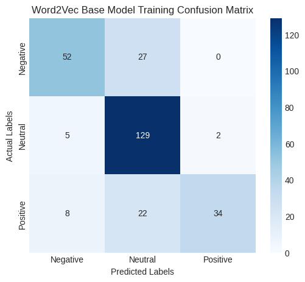

```python
# Plot confusion matrix w/ Training
plot_confusion_matrix(w2v_base_model, x_training_data_w2v, y_training_data, w2v_model_title + ' Training Confusion Matrix')
```

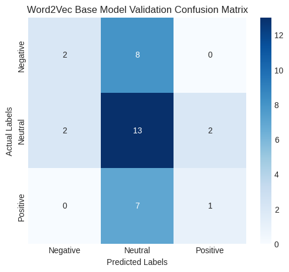

```python
# Plot confusion matrix w/ validation
plot_confusion_matrix(w2v_base_model, x_validation_data_w2v, y_validation_data,  w2v_model_title + ' Validation Confusion Matrix')
```

```python
# Create performance w/ training data
w2v_training_perf = model_performance_classification_sklearn(w2v_base_model, x_training_data_w2v, y_training_data)
```

```python
# Create performance w/ validation data
w2v_validation_perf = model_performance_classification_sklearn(w2v_base_model, x_validation_data_w2v, y_validation_data)
```

```python
show_performance(w2v_training_perf, w2v_model_title + ' Training')
show_performance(w2v_validation_perf, w2v_model_title + ' Validation')
show_fitting_perf(w2v_training_perf, w2v_validation_perf, w2v_model_title)
```

```
+--------------------------------+
|  WORD2VEC BASE MODEL TRAINING  |
+--------------------------------+
| Performance

   Accuracy    Recall  Precision        F1
0  0.770609  0.770609   0.796438  0.761006

+----------------------------------+
|  WORD2VEC BASE MODEL VALIDATION  |
+----------------------------------+
| Performance

   Accuracy    Recall  Precision        F1
0  0.457143  0.457143   0.444558  0.403826

Gap: 0.3571803592453844

Word2Vec Base Model fitting: overfitting.
```

**Base Model GloVe**

```python
gloVe_model_title = 'GloVe Base Model'
gloVe_base_model = fit_model(rf_base_model(), x_training_data_gloVe, y_training_data)
print(f"Post-Training Check: gloVe_base_model expects {gloVe_base_model.n_features_in_} features.")
```

```
Post-Training Check: gloVe_base_model expects 100 features.
```

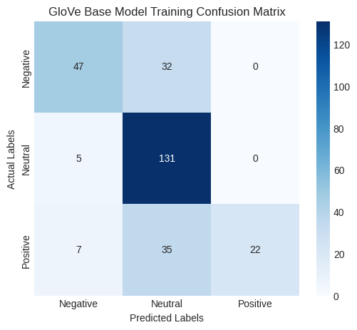

```python
# Plot GloVe confusion matrix w/ training
plot_confusion_matrix(gloVe_base_model, x_training_data_gloVe, y_training_data, gloVe_model_title + ' Training Confusion Matrix')
```

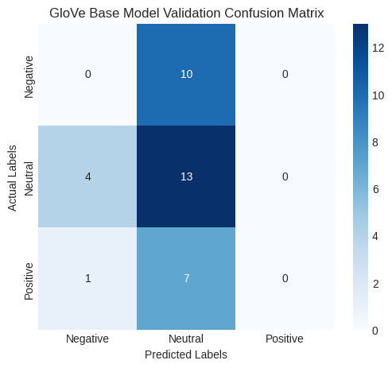

```python
# Plot GloVe confusion matrix w/ validation
plot_confusion_matrix(gloVe_base_model, x_validation_data_gloVe, y_validation_data, gloVe_model_title + ' Validation Confusion Matrix')
```

```python
# Create GloVe performance w/ training data
gloVe_training_perf = model_performance_classification_sklearn(gloVe_base_model, x_training_data_gloVe, y_training_data)
```

```python
# Create GloVe performance w/ validation data
gloVe_validation_perf = model_performance_classification_sklearn(gloVe_base_model, x_validation_data_gloVe, y_validation_data)
```

```python
show_performance(gloVe_training_perf, gloVe_model_title + ' Training')
show_performance(gloVe_validation_perf, gloVe_model_title + ' Validation')
show_fitting_perf(gloVe_training_perf, gloVe_validation_perf, gloVe_model_title)
```

```
+-----------------------------+
|  GLOVE BASE MODEL TRAINING  |
+-----------------------------+
| Performance

   Accuracy    Recall  Precision        F1
0  0.716846  0.716846   0.777462  0.692611

+-------------------------------+
|  GLOVE BASE MODEL VALIDATION  |
+-------------------------------+
| Performance

   Accuracy    Recall  Precision        F1
0  0.371429  0.371429   0.210476  0.268693

Gap: 0.4239177972612049
Message: The model is too complex (high variance), but its absolute performance is also low. Action: Drastically increase regularization/simplify the model.

GloVe Base Model fitting: overfitting.
```

**Base Model Sentence Transformer**

```python
st_model_title = 'Sentence Transformer Base Model'
st_base_model = fit_model(rf_base_model(), x_training_data_st, y_training_data)
print(f"Post-Training Check: st_base_model expects {st_base_model.n_features_in_} features.")
```

```
Post-Training Check: st_base_model expects 384 features.
```

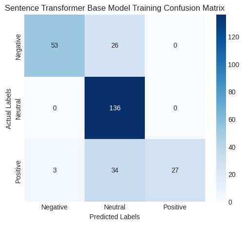

```python
# Plot Sentence Transformer confusion matrix w/ training data
plot_confusion_matrix(st_base_model, x_training_data_st, y_training_data, st_model_title + ' Training Confusion Matrix')
```

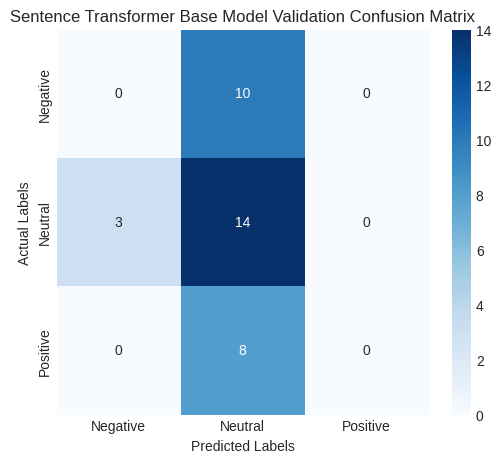

```python
# Plot Sentence Transformer confusion matrix w/ validation data
plot_confusion_matrix(st_base_model, x_validation_data_st, y_validation_data, st_model_title + ' Validation Confusion Matrix')
```

```python
# Create Sentence Transformer performance w/ training data
st_training_perf = model_performance_classification_sklearn(st_base_model, x_training_data_st, y_training_data)
```

```python
# Create Sentence Transformer performance w/ validation data
st_validation_perf = model_performance_classification_sklearn(st_base_model, x_validation_data_st, y_validation_data)
```

```python
show_performance(st_training_perf, st_model_title + ' Training')
show_performance(st_validation_perf, st_model_title + ' Validation')
show_fitting_perf(st_training_perf, st_validation_perf, st_model_title)
```

```
+--------------------------------------------+
|  SENTENCE TRANSFORMER BASE MODEL TRAINING  |
+--------------------------------------------+
| Performance

   Accuracy    Recall  Precision        F1
0  0.774194  0.774194    0.83561  0.757811

+----------------------------------------------+
|  SENTENCE TRANSFORMER BASE MODEL VALIDATION  |
+----------------------------------------------+
| Performance

   Accuracy  Recall  Precision        F1
0       0.4     0.4     0.2125  0.277551

Gap: 0.4802602281747742

Sentence Transformer Base Model fitting: overfitting.
```

### Building Tuned Models

```python
def tune_model(
    mod: RandomForestClassifier,
    x_training_data: pd.DataFrame,
    y_training_data: pd.DataFrame,
    tuned_title=''
) -> RandomForestClassifier:

    start_time = start_timer()
    show_banner(f'Tuning {tuned_title} Model')

    # Defined globally or passed into the function scope
    parameters = {
        # Force simplicity: max_depth cannot be high
        "max_depth": [3, 4, 5, 6],

        # Increase min_samples_leaf aggressively (fights overfitting)
        "min_samples_leaf": randint(20, 60),

        # Increase min_samples_split aggressively (fights overfitting)
        "min_samples_split": randint(40, 100),

        # Keeping n_estimators fixed or slightly varied for stability
        "n_estimators": [300, 500, 700],

        # Keep max_features conservative
        "max_features": ["sqrt", 0.4]
    }

    # Use the aggressive parameter distribution
    random_search = RandomizedSearchCV(
        estimator=mod,
        param_distributions=parameters, # <-- Using the aggressive space
        n_iter=CV_RANDOM_SEARCH_CNT,
        scoring='f1_weighted',
        cv=StratifiedKFold(
            CV_FOLDS,
            shuffle=True,
            random_state=SEED
        ),
        n_jobs=USE_ALL_PROCS,
        random_state=SEED
    )

    random_search.fit(x_training_data, y_training_data)

    print('Best parameters found: ', random_search.best_params_)
    print('Best CV F1-weighted Score: ', random_search.best_score_)

    # Get the best model
    best_rf = random_search.best_estimator_

    # Re-fit on the full training set (optional, but good practice before prediction)
    best_rf.fit(x_training_data, y_training_data)

    show_timer(start_time) # Placeholder for timer

    # NOTE: The return type is RandomForestClassifier (the best model), not RandomizedSearchCV
    return best_rf
```

```python
# Create a new model for tuning.  This will be used for each model.
def rf_tuned_model() -> RandomForestClassifier:
    return RandomForestClassifier(
        max_depth=4,             # Good controlled depth
        min_samples_leaf=40,     # Strong pruning to prevent initial severe overfitting
        min_samples_split=80,    # Strong split guardrail
        n_estimators=500,
        max_features='sqrt',
        random_state=SEED
    )
```

**Tuned Model Word2Vec**

```python
# Create Tuned Model
# 5m 20s 337ms
# Run Time: 41m 31s 193ms GPU
w2v_tuned_model_title = 'Word2Vec Tuned Model'
w2v_tuned_model = tune_model(rf_tuned_model(), x_training_data_w2v, y_training_data, w2v_tuned_model_title)
print(f"w2v_tuned_model expects: {w2v_tuned_model.n_features_in_} features.")
```

```
+-------------------------------------+
|  TUNING WORD2VEC TUNED MODEL MODEL  |
+-------------------------------------+

Best parameters found:  {'max_depth': 4, 'max_features': 0.4, 'min_samples_leaf': 22, 'min_samples_split': 76, 'n_estimators': 700}
Best CV F1-weighted Score:  0.4332193509866328

Run Time: 3m 23s 559ms
w2v_tuned_model expects: 300 features.
```

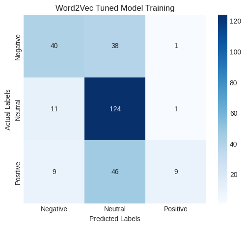

```python
# Plot confusion matrix w/ training data
plot_confusion_matrix(w2v_tuned_model, x_training_data_w2v, y_training_data, w2v_tuned_model_title + ' Training')
```

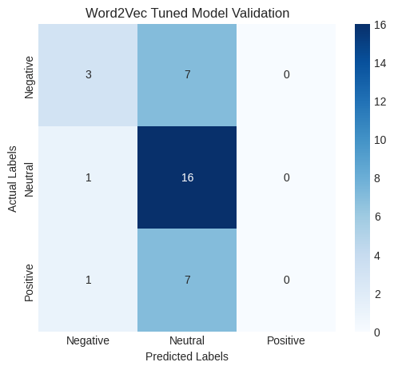

```python
# Plot confusion matrix w/ validation data
plot_confusion_matrix(w2v_tuned_model, x_validation_data_w2v, y_validation_data, w2v_tuned_model_title + ' Validation')
```

```python
# Create performance w/ training data
w2v_tuned_training_perf = model_performance_classification_sklearn(w2v_tuned_model, x_training_data_w2v, y_training_data)
```

```python
# Create performance w/ validation data
w2v_tuned_validation_perf = model_performance_classification_sklearn(w2v_tuned_model, x_validation_data_w2v, y_validation_data)
```

```python
show_performance(w2v_tuned_training_perf, w2v_tuned_model_title + ' Training')
show_performance(w2v_tuned_validation_perf, w2v_tuned_model_title + ' Validation')
show_fitting_perf(w2v_tuned_training_perf, w2v_tuned_validation_perf, w2v_tuned_model_title)
```

```
+---------------------------------+
|  WORD2VEC TUNED MODEL TRAINING  |
+---------------------------------+
| Performance

   Accuracy    Recall  Precision        F1
0  0.620072  0.620072   0.667051  0.569441

+-----------------------------------+
|  WORD2VEC TUNED MODEL VALIDATION  |
+-----------------------------------+
| Performance

   Accuracy    Recall  Precision        F1
0  0.542857  0.542857   0.430476  0.444985

Gap: 0.12445655071243039
Message: The model is too complex (high variance), but its absolute performance is also low. Action: Drastically increase regularization/simplify the model.

Word2Vec Tuned Model fitting: overfitting.
```

**Tuned Model GloVe**

```python
# Create Tuned Model
gloVe_tuned_model_title = 'GloVe Tuned Model'
gloVe_tuned_model = tune_model(rf_tuned_model(), x_training_data_gloVe, y_training_data, gloVe_tuned_model_title)
print(f"gloVe_tuned_model expects: {gloVe_tuned_model.n_features_in_} features.")
```

```
+----------------------------------+
|  TUNING GLOVE TUNED MODEL MODEL  |
+----------------------------------+

Best parameters found:  {'max_depth': 3, 'max_features': 0.4, 'min_samples_leaf': 21, 'min_samples_split': 59, 'n_estimators': 700}
Best CV F1-weighted Score:  0.4112273180456822

Run Time: 2m 49s 502ms
gloVe_tuned_model expects: 100 features.
```